# Injury prediction modelling in football players

Juan R. Gonzalez, Eva Ferrer and Gil Rodas

Bioinformatics Research Group in Epidemiolgy (BRGE), Barcelona Insitute for Global Health (ISGlobal)  
Department of Mathematics, Autonomous University of Barcelona (UAB)  
FCB innovation hub

juanr.gonzalez@isglobal.org

2023-04-21

# 1 Getting started

Load the required libraries

```r
library(readxl)
library(tidyverse)
library(lubridate)
library(tsibble)
library(fuzzyjoin)
library(reshape2)
library(TTR)
library(zoo)
library(magrittr)
library(ggfortify)
library(broom)
library(bbplot)
library(ggplotify)
library(plotly)
library(tidymv)
library(forcats)
library(dlnm)
library(survival)
library(splines)
library(mgcv)
library(SNPassoc)
library(kableExtra)
library(RColorBrewer)
library(pROC)
library(gtsummary)
library(recipes)
library(tidy.outliers)
library(DescTools)
library(voxel)
library(grid)
library(gridExtra)
library(survminer)
```

and write some functions

```r
# Acture to Chronic Workload Ratio
ACWR <- function(x){
 acute <- round(EMA(value, n = 1, ratio = 2/(7+1)), 2)
 chronic <- round(EMA(value, n = 1, ratio = 2/(42+1)), 2)
 acwr <- acute/chronic
 return(acwr)
}


outliers <- function(x, limit=1.5) {

  Q1 <- quantile(x, probs=.25, na.rm=TRUE)
  Q3 <- quantile(x, probs=.75, na.rm=TRUE)
  iqr <- Q3-Q1

 upper_limit <- Q3 + (iqr*limit)
 lower_limit <- Q1 - (iqr*limit)

 ans <- x > upper_limit | x < lower_limit
 return(ans)
}

remove_outliers <- function(df, cols = names(df), ...) {
  for (col in cols) {
    df <- df[!outliers(df[[col]], ...),]
  }
  df
}



source("R/functions_final.R")
```

# 2 Load data

## 2.1 Get external load data

Let us import the external load data of 2019-20 and 2020-21 seasons

```r
workload_2019_2020 <- read_csv("workload_2019_2020.csv") %>%
  arrange(code, Date) %>%
  tsibble(key = code, index=Date) %>% fill_gaps() %>%
  mutate_at(-c(1:2), ~ tidyr::replace_na(.,0)) %>%
  rename_all(janitor::make_clean_names)


workload_2020_2021 <- read_csv("workload_2020_2021.csv") %>%
  arrange(code, Date) %>%
  tsibble(key = code, index=Date) %>% fill_gaps() %>%
  mutate_at(-c(1:2), ~ tidyr::replace_na(.,0)) %>%
  rename_all(janitor::make_clean_names)
```

```r
workload <- bind_rows(workload_2019_2020, workload_2020_2021) %>%
  tsibble(key = code, index=date) %>% fill_gaps() %>%
  mutate_at(-c(1:2), ~ tidyr::replace_na(.,0)) %>%
  mutate(dist_m = dist_m/10^3) %>%
  as_tibble()
```

This is the total number of players

```r
length(table(workload$code))
```

```
[1] 24
```

and the total number of days we have monitored per player

```r
table(workload$code)
```

```
 FCB1 FCB10 FCB11 FCB12 FCB13 FCB14 FCB15 FCB16 FCB17 FCB18 FCB19
  592   652   652   536   652   635   652   652   650   646   341
 FCB2 FCB20 FCB21 FCB22 FCB23 FCB24  FCB3  FCB4  FCB5  FCB6  FCB7
  592   649   652   566   645   297   652   648   652   651   651
 FCB8  FCB9
  647   652
```

Let us select specific features

```r
workload <- workload %>%
  dplyr::select(code, date, duration_min, dist_m, dist_min_m_min,
                rel_hsr_m, rel_hsr_min_m_min, hmld_m,
                hmld_min_m_min, acc_3_m_s2_min_count_min,
                acc_3_m_s2_dist_m, acc_3_m_s2_count,
                dec_3_m_s2_min_count_min, dec_3_m_s2_dist_m,
                dec_3_m_s2_count, pl_a_u, pl_min_a_u_min)
```

## 2.2 General data

Let us import the general data of players

```r
datos <- read_excel("peso_fat_1_temp.xlsx")
colnames(datos) <- c("code", "race", "position", "age", "height", "weight", "fat", "date")
datos <- datos %>% arrange(code, date) %>%
  mutate(bmi = weight/height**2,
         age2 = as.numeric(as.Date(date) - as.Date(age))/365.25,
         date = as.Date(date))
```

## 2.3 Get injuries data

Let us start by loading injuries

```r
injuries <- read_excel("cuadro resumen 3 temporadas lesiones.xlsx")[,-1] %>%
  rename_all(janitor::make_clean_names) %>%
  rename(code = codi) %>%
  filter(data>=min(workload$date)) %>%
  mutate(entreno_partit=ifelse(entreno_partit=="Patrtit", "Partit", entreno_partit)) %>%
  group_by(code) %>% mutate(n_injur=1:n()) %>%
  ungroup()
```

These are the total number of injuries

```r
injuries %>%
  dplyr::select(tipus_lesio, dreta_esquerra, entreno_partit, n_injur) %>% tbl_summary()
```

| **Characteristic** | **N = 89**<sup>1</sup> |
| --- | --- |
| tipus_lesio |  |
| Cardiac | 1 (1.1%) |
| Cartileg | 5 (5.6%) |
| Cutanea | 1 (1.1%) |
| Cutani | 1 (1.1%) |
| LLigament | 19 (21%) |
| Musc/tendo | 7 (7.9%) |
| Muscular | 37 (42%) |
| Ossia | 7 (7.9%) |
| Tendó | 11 (12%) |
| dreta_esquerra |  |
| / | 1 (1.1%) |
| Dreta | 49 (55%) |
| Esquerra | 39 (44%) |
| entreno_partit |  |
| Entreno | 56 (63%) |
| Partit | 33 (37%) |
| n_injur |  |
| 1 | 28 (31%) |
| 2 | 21 (24%) |
| 3 | 17 (19%) |
| 4 | 10 (11%) |
| 5 | 5 (5.6%) |
| 6 | 4 (4.5%) |
| 7 | 2 (2.2%) |
| 8 | 2 (2.2%) |

<sup>1</sup> n (%)

```r
injuries %>% filter(data<=dmy("30-06-2021")) %>%
  dplyr::select(tipus_lesio, dreta_esquerra, entreno_partit, n_injur) %>% tbl_summary()
```

| **Characteristic** | **N = 48**<sup>1</sup> |
| --- | --- |
| tipus_lesio |  |
| Cartileg | 4 (8.3%) |
| Cutani | 1 (2.1%) |
| LLigament | 8 (17%) |
| Musc/tendo | 2 (4.2%) |
| Muscular | 25 (52%) |
| Ossia | 4 (8.3%) |
| Tendó | 4 (8.3%) |
| dreta_esquerra |  |
| Dreta | 29 (60%) |
| Esquerra | 19 (40%) |
| entreno_partit |  |
| Entreno | 31 (65%) |
| Partit | 17 (35%) |
| n_injur |  |
| 1 | 20 (42%) |
| 2 | 15 (31%) |
| 3 | 6 (12%) |
| 4 | 4 (8.3%) |
| 5 | 3 (6.2%) |

<sup>1</sup> n (%)

```r
injuries %>% filter(data>=dmy("1-07-2021")) %>%
  dplyr::select(tipus_lesio, dreta_esquerra, entreno_partit, n_injur) %>% tbl_summary()
```

| **Characteristic** | **N = 41**<sup>1</sup> |
| --- | --- |
| tipus_lesio |  |
| Cardiac | 1 (2.4%) |
| Cartileg | 1 (2.4%) |
| Cutanea | 1 (2.4%) |
| LLigament | 11 (27%) |
| Musc/tendo | 5 (12%) |
| Muscular | 12 (29%) |
| Ossia | 3 (7.3%) |
| Tendó | 7 (17%) |
| dreta_esquerra |  |
| / | 1 (2.4%) |
| Dreta | 20 (49%) |
| Esquerra | 20 (49%) |
| entreno_partit |  |
| Entreno | 25 (61%) |
| Partit | 16 (39%) |
| n_injur |  |
| 1 | 8 (20%) |
| 2 | 6 (15%) |
| 3 | 11 (27%) |
| 4 | 6 (15%) |
| 5 | 2 (4.9%) |
| 6 | 4 (9.8%) |
| 7 | 2 (4.9%) |
| 8 | 2 (4.9%) |

<sup>1</sup> n (%)

Create a variable `injury` Available/Injured using the information available on date of injury and keep only our type of injuries of interest

```r
injuries <- injuries %>%
  arrange(code, data) %>% mutate(data=as_date(data)) %>%
  mutate(injury = ifelse(is.na(data), "Available", "Injured")) %>%
  filter(!tipus_lesio%in%c("Cardiac", "Cutanea", "Cutani", "Ossia")) %>%
  group_by(code) %>%
  mutate(n_injur=1:n()) %>%
  ungroup()
# , "Cartileg"
```

Select injuries for the analyzed period

```r
injuries <- injuries %>% filter(code%in%paste0("FCB", 1:24) &
                                    data<=dmy("30-06-2021"))
```

Let us describe the injuries

```r
injuries %>%
  dplyr::select(tipus_lesio, dreta_esquerra, entreno_partit, n_injur) %>% tbl_summary()
```

| **Characteristic** | **N = 43**<sup>1</sup> |
| --- | --- |
| tipus_lesio |  |
| Cartileg | 4 (9.3%) |
| LLigament | 8 (19%) |
| Musc/tendo | 2 (4.7%) |
| Muscular | 25 (58%) |
| Tendó | 4 (9.3%) |
| dreta_esquerra |  |
| Dreta | 25 (58%) |
| Esquerra | 18 (42%) |
| entreno_partit |  |
| Entreno | 28 (65%) |
| Partit | 15 (35%) |
| n_injur |  |
| 1 | 19 (44%) |
| 2 | 13 (30%) |
| 3 | 6 (14%) |
| 4 | 3 (7.0%) |
| 5 | 2 (4.7%) |

<sup>1</sup> n (%)

This is the distribution of injuries by player

```r
injuries %>% filter(injury=="Injured") %>% group_by(code) %>%
  dplyr::summarize(n())
```

```
# A tibble: 19 × 2
   code  `n()`
   <chr> <int>
 1 FCB10     1
 2 FCB11     5
 3 FCB12     3
 4 FCB14     5
 5 FCB15     2
 6 FCB16     2
 7 FCB17     2
 8 FCB18     1
 9 FCB19     4
10 FCB2      1
11 FCB21     3
12 FCB22     2
13 FCB23     2
14 FCB24     3
15 FCB3      1
16 FCB4      1
17 FCB5      1
18 FCB7      2
19 FCB9      2
```

Let us visualize the follow-up period

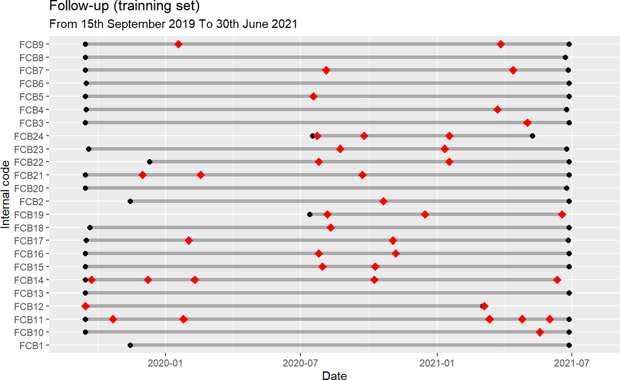

```r
workload %>% group_by(code) %>% summarise(min=min(date), max=max(date)) %>%
  pivot_longer(cols = min:max, names_to = "time") %>%
  ggplot(aes(x = value, y = code)) +
  geom_line(size = 1.5, alpha = 0.3) +
  geom_point(size = 2) +
  labs(y = 'Internal code', x = "Date",
       title = 'Follow-up (trainning set)',
       subtitle = 'From 15th September 2019 To 30th June 2021') +
  geom_point(data=injuries, aes(x=data, y=code),
             shape=23, fill="red", color="red", size = 2.5) +
  scale_x_date(limits = c(dmy("1-09-2019"), dmy("31-07-2021")))
```

Let us create the final dataset by merging workload information with injuries data

```r
temp <- injuries %>% filter(injury=="Injured")
fcbData <- workload %>% full_join(temp,
                                  by=c("code"="code",
                                       "date"="data")) %>%
  arrange(code, date) %>%
  mutate(injury = replace(injury, is.na(injury), "Available"),
         injur = ifelse(injury=="Available", 0, 1)) %>%
  group_by(code) %>%
  fill(entreno_partit, .direction="downup") %>%
  fill(re_injury, .direction="downup") %>%
  fill(n_injur, .direction="down") %>%
  mutate(n_injur=replace_na(n_injur, 0)) %>%
# this is to recover the missings we introduce with full_join (to do not lose bmi, fat ,...)
  filter(!is.na(duration_min))


# let us create time variables (Calendar, Day, Day_season)
fcbData <- fcbData %>%
  mutate(Calendar = as.numeric(date - min(date) + 1)) %>%
  group_by(code) %>%
  mutate(Day = Calendar - min(Calendar) + 1) %>%
  ungroup() %>%
  mutate(season = ifelse(date <= dmy("30-06-2020"), "2019-20", "2020-21")) %>%
  group_by(season, code) %>%
  mutate(Day_season=1:n()) %>%
  ungroup()


# re-order columns
fcbData <- fcbData %>%
  dplyr::select(code, date,  Calendar, Day, season, Day_season,
                lesio:injury, injur, duration_min:pl_min_a_u_min)
```

The total number of injuries are

```r
table(fcbData$injury)
```

```
Available   Injured
    14575        40
```

with this type of lesion

```r
temp <- table(fcbData$tipus_lesio)
temp
```

```
  Cartileg  LLigament Musc/tendo   Muscular      Tendó
         1          8          2         25          4
```

```r
prop.table(temp)*100
```

```
  Cartileg  LLigament Musc/tendo   Muscular      Tendó
       2.5       20.0        5.0       62.5       10.0
```

side

```r
table(fcbData$dreta_esquerra)
```

```
   Dreta Esquerra
      23       17
```

```r
prop.table(table(fcbData$dreta_esquerra))
```

```
   Dreta Esquerra
   0.575    0.425
```

timing

```r
table(fcbData$entreno_partit)
```

```
Entreno  Partit
   7677    3747
```

```r
prop.table(table(fcbData$entreno_partit))
```

```
  Entreno    Partit
0.6720063 0.3279937
```

Number of recurrences

```r
temp <- fcbData %>% filter(injury=="Injured") %>% group_by(code) %>%
  dplyr::summarize(N=n())
table(temp$N)
```

```
1 2 3 4 5
7 7 2 2 1
```

```r
prop.table(table(temp$N))*100
```

```
        1         2         3         4         5
36.842105 36.842105 10.526316 10.526316  5.263158
```

Injuries with 1000 hours

```r
sum(fcbData$injur)/sum(fcbData$duration_min/60)*1000
```

```
[1] 5.315108
```

```r
a <- fcbData %>% filter(entreno_partit == "Entreno")
sum(a$injur)/sum(a$duration_min/60)*1000
```

```
[1] 6.653615
```

```r
a <- fcbData %>% filter(entreno_partit == "Partit")
sum(a$injur)/sum(a$duration_min/60)*1000
```

```
[1] 7.758445
```

# 3 Quality control

First, let us check for discrepancies in training load data

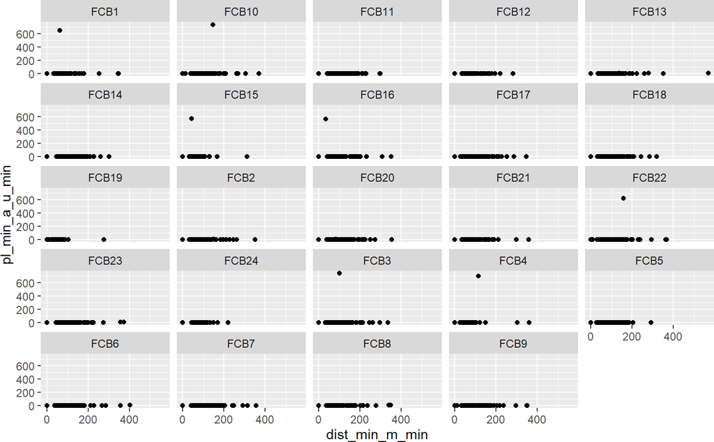

Figure 1: Quality control of player load  
The figure depicts the correlation between player load and distance showing some discrepancies (they are not in the diagonal)

```r
ggplot(fcbData, aes( dist_min_m_min , pl_min_a_u_min)) +
  geom_point() + facet_wrap(~code)
```

Let us impute by the predicted value

```r
mm <- lm(pl_min_a_u_min ~ dist_min_m_min, data=fcbData)
fcbData <- fcbData %>% mutate(residuals = mm$residuals,
                              predicted = predict(mm)) %>%
  mutate(pl_min_a_u_min = ifelse(abs(residuals)>3, predicted, pl_min_a_u_min)) %>%
  dplyr::select(-c(residuals, predicted))
```

Now the relationship is as expected

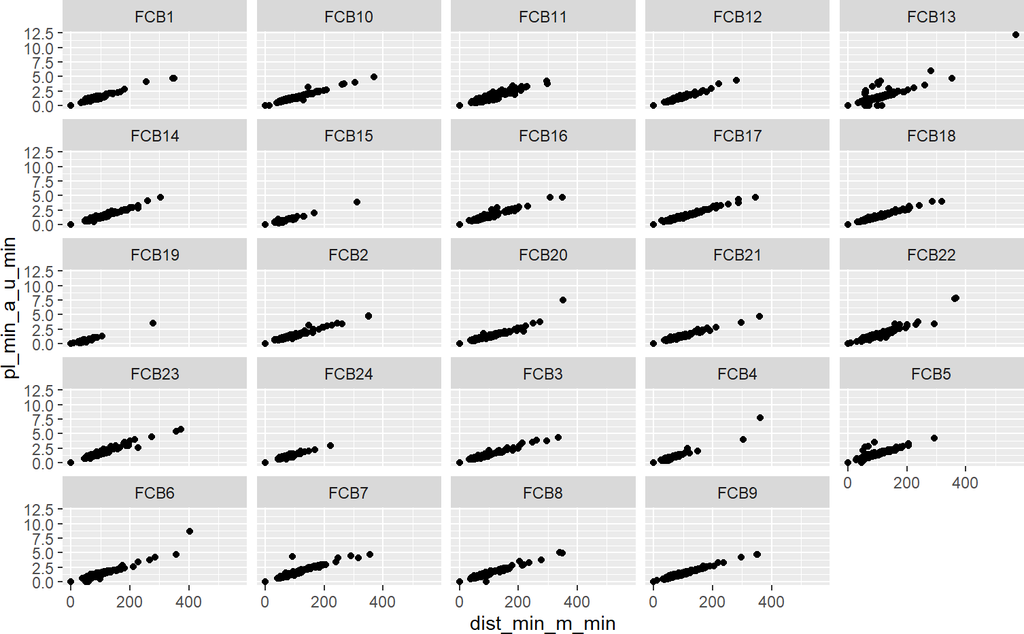

```r
ggplot(fcbData, aes( dist_min_m_min , pl_min_a_u_min)) +
  geom_point() + facet_wrap(~code)
```

Now the same for these two variables

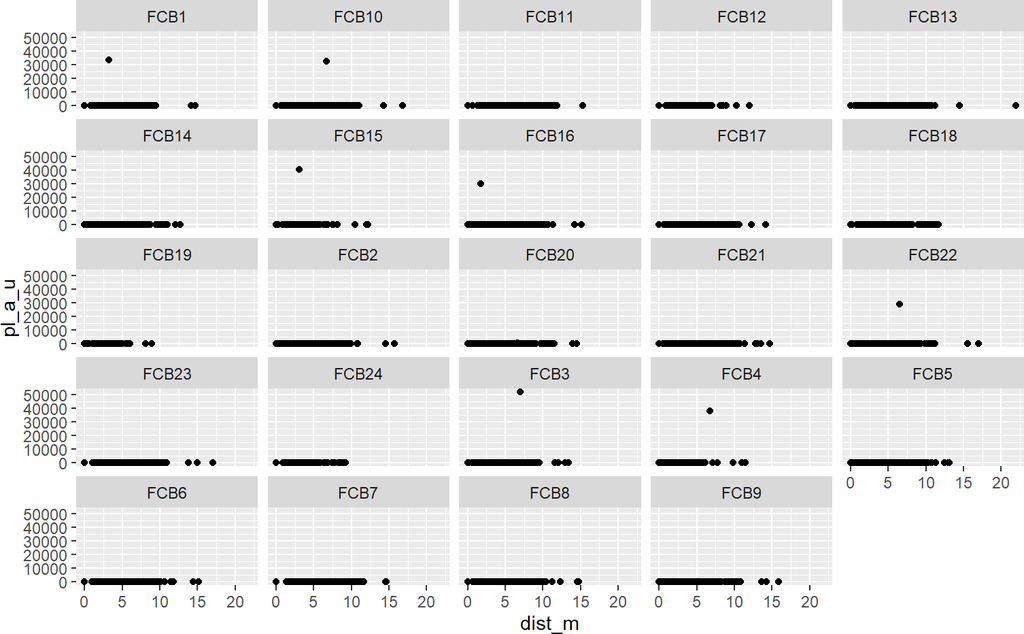

Figure 3: Quality control of player load  
The figure depicts the correlation between player load and distance showing some discrepancies (they are not in the diagonal)

```r
ggplot(fcbData, aes( dist_m , pl_a_u)) +
  geom_point() + facet_wrap(~code)
```

```r
mm <- lm(pl_a_u ~ dist_m, data=fcbData)
fcbData <- fcbData %>% mutate(residuals = mm$residuals,
                              predicted = predict(mm)) %>%
  mutate(pl_a_u = ifelse(abs(residuals)>3, predicted, pl_a_u)) %>%
  dplyr::select(-c(residuals, predicted))
```

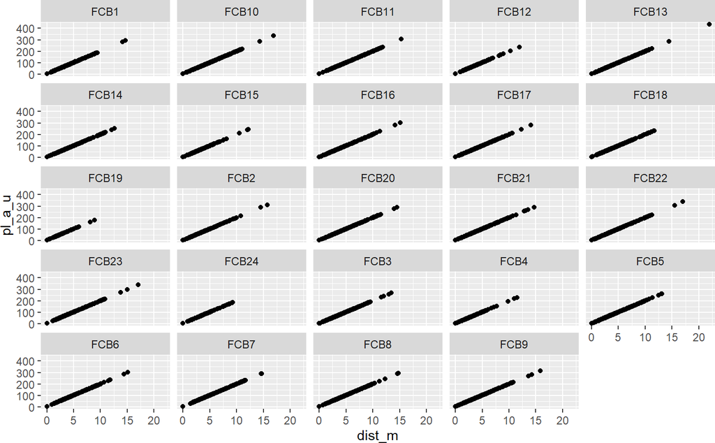

Figure 4: Quality control of player load  
The figure depicts the correlation between player load and distance showing a perfect agreement among these variables after quality control step.

```r
ggplot(fcbData, aes( dist_m , pl_a_u)) +
  geom_point() + facet_wrap(~code)
```

Now, let us check for possible outliers

```r
fcbData %>% dplyr::select(duration_min:pl_min_a_u_min) %>% summary()
```

```
  duration_min        dist_m       dist_min_m_min     rel_hsr_m
 Min.   :  0.00   Min.   : 0.000   Min.   :  0.00   Min.   :  0.0
 1st Qu.:  0.00   1st Qu.: 0.000   1st Qu.:  0.00   1st Qu.:  0.0
 Median :  1.20   Median : 0.000   Median :  0.00   Median :  0.0
 Mean   : 30.90   Mean   : 2.298   Mean   : 40.83   Mean   : 21.2
 3rd Qu.: 59.38   3rd Qu.: 3.945   3rd Qu.: 73.54   3rd Qu.: 10.1
 Max.   :271.38   Max.   :21.925   Max.   :568.87   Max.   :590.6
 rel_hsr_min_m_min     hmld_m       hmld_min_m_min
 Min.   : 0.0000   Min.   :   0.0   Min.   :   0.000
 1st Qu.: 0.0000   1st Qu.:   0.0   1st Qu.:   0.000
 Median : 0.0000   Median :   0.0   Median :   0.000
 Mean   : 0.4980   Mean   : 344.8   Mean   :   5.939
 3rd Qu.: 0.1848   3rd Qu.: 580.1   3rd Qu.:  10.764
 Max.   :89.2362   Max.   :2890.1   Max.   :3294.716
 acc_3_m_s2_min_count_min acc_3_m_s2_dist_m acc_3_m_s2_count
 Min.   :0.0000           Min.   :  0.0     Min.   :  0.00
 1st Qu.:0.0000           1st Qu.:  0.0     1st Qu.:  0.00
 Median :0.0000           Median :  0.0     Median :  0.00
 Mean   :0.2760           Mean   :100.0     Mean   : 14.93
 3rd Qu.:0.4903           3rd Qu.:178.7     3rd Qu.: 28.00
 Max.   :6.5091           Max.   :928.9     Max.   :150.00
 dec_3_m_s2_min_count_min dec_3_m_s2_dist_m dec_3_m_s2_count
 Min.   :0.0000           Min.   :  0.00    Min.   :  0.00
 1st Qu.:0.0000           1st Qu.:  0.00    1st Qu.:  0.00
 Median :0.0000           Median :  0.00    Median :  0.00
 Mean   :0.2999           Mean   : 58.59    Mean   : 16.52
 3rd Qu.:0.5550           3rd Qu.:100.99    3rd Qu.: 31.00
 Max.   :5.0195           Max.   :626.00    Max.   :135.00
     pl_a_u        pl_min_a_u_min
 Min.   :  4.549   Min.   : 0.0000
 1st Qu.:  4.549   1st Qu.: 0.0000
 Median :  4.549   Median : 0.0000
 Mean   : 49.564   Mean   : 0.5784
 3rd Qu.: 81.832   3rd Qu.: 1.0673
 Max.   :434.101   Max.   :12.1574
```

```r
# remove outliers
fcbData <- fcbData %>% mutate(
  pl_min_a_u_min = ifelse(pl_min_a_u_min>5, 5, pl_min_a_u_min),
  pl_a_u = ifelse(pl_a_u>300, 300, pl_a_u),
  dist_min_m_min = ifelse(dist_min_m_min>400, 400, pl_min_a_u_min),
  dist_m = ifelse(dist_m>12, 12, dist_m),
  rel_hsr_m = ifelse(rel_hsr_m>130, 130,
                             rel_hsr_m),
  rel_hsr_min_m_min = ifelse(rel_hsr_min_m_min>25, 5,
                             rel_hsr_min_m_min))

fcbData %>% dplyr::select(duration_min:pl_min_a_u_min) %>% summary()
```

```
  duration_min        dist_m       dist_min_m_min
 Min.   :  0.00   Min.   : 0.000   Min.   :  0.0000
 1st Qu.:  0.00   1st Qu.: 0.000   1st Qu.:  0.0000
 Median :  1.20   Median : 0.000   Median :  0.0000
 Mean   : 30.90   Mean   : 2.291   Mean   :  0.6308
 3rd Qu.: 59.38   3rd Qu.: 3.945   3rd Qu.:  1.0673
 Max.   :271.38   Max.   :12.000   Max.   :400.0000
   rel_hsr_m      rel_hsr_min_m_min     hmld_m
 Min.   :  0.00   Min.   : 0.0000   Min.   :   0.0
 1st Qu.:  0.00   1st Qu.: 0.0000   1st Qu.:   0.0
 Median :  0.00   Median : 0.0000   Median :   0.0
 Mean   : 16.86   Mean   : 0.4022   Mean   : 344.8
 3rd Qu.: 10.10   3rd Qu.: 0.1848   3rd Qu.: 580.1
 Max.   :130.00   Max.   :23.0039   Max.   :2890.1
 hmld_min_m_min     acc_3_m_s2_min_count_min acc_3_m_s2_dist_m
 Min.   :   0.000   Min.   :0.0000           Min.   :  0.0
 1st Qu.:   0.000   1st Qu.:0.0000           1st Qu.:  0.0
 Median :   0.000   Median :0.0000           Median :  0.0
 Mean   :   5.939   Mean   :0.2760           Mean   :100.0
 3rd Qu.:  10.764   3rd Qu.:0.4903           3rd Qu.:178.7
 Max.   :3294.716   Max.   :6.5091           Max.   :928.9
 acc_3_m_s2_count dec_3_m_s2_min_count_min dec_3_m_s2_dist_m
 Min.   :  0.00   Min.   :0.0000           Min.   :  0.00
 1st Qu.:  0.00   1st Qu.:0.0000           1st Qu.:  0.00
 Median :  0.00   Median :0.0000           Median :  0.00
 Mean   : 14.93   Mean   :0.2999           Mean   : 58.59
 3rd Qu.: 28.00   3rd Qu.:0.5550           3rd Qu.:100.99
 Max.   :150.00   Max.   :5.0195           Max.   :626.00
 dec_3_m_s2_count     pl_a_u        pl_min_a_u_min
 Min.   :  0.00   Min.   :  4.549   Min.   :0.0000
 1st Qu.:  0.00   1st Qu.:  4.549   1st Qu.:0.0000
 Median :  0.00   Median :  4.549   Median :0.0000
 Mean   : 16.52   Mean   : 49.545   Mean   :0.5767
 3rd Qu.: 31.00   3rd Qu.: 81.832   3rd Qu.:1.0673
 Max.   :135.00   Max.   :300.000   Max.   :5.0000
```

# 4 Data visualization

Here we can see the information for total load

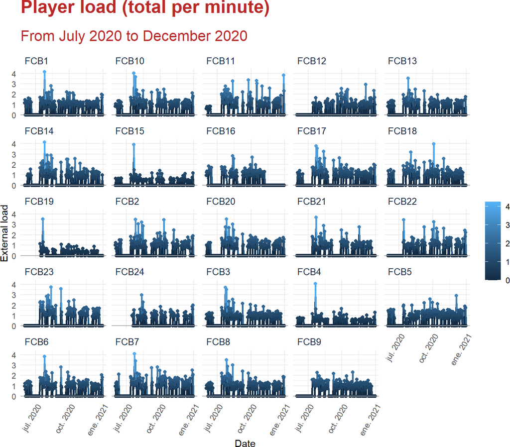

```r
font <- 'Helvetica'
fcbData.no <- fcbData %>% remove_outliers(cols = "pl_min_a_u_min", limit=3)
p <- ggplot(fcbData.no, aes(date, pl_min_a_u_min, color=pl_min_a_u_min)) +
  geom_line(size=1) +  geom_point() + facet_wrap('code', nrow=5)

p <- p + labs(y = 'External load', x = "Date", color='pl_min_a_u_min',
       title = 'Player load (total per minute)',
       subtitle = 'From July 2020 to December 2020') +
  theme_minimal() +
  geom_hline(yintercept = 0, color='darkgrey')

p <- p +
  theme(
    plot.title = element_text(family = font,
                              size = 20,
                              face = "bold",
                              color = "#b92928"),
    plot.subtitle = element_text(family = font,
                                 size = 16,
                                 margin = ggplot2::margin(9,0,9,0),
                                 color = '#b92928'),
    strip.text = element_text(size  = 10,  hjust = 0, colour = '#142642'),
  )

p <- p + theme(axis.text.x=element_text(angle=60, hjust=1)) +
  scale_x_date(date_labels = "%b %Y",
               limit=c(as.Date("2020-06-01"), as.Date("2020-12-31"))) +
  labs(color="")

p
```

Let us put our data in long format to facilitate downstream analyses

```r
fcbDataLong <- melt(fcbData, id.vars = c(1:19)) %>%
    group_by(code, variable) %>%
    arrange(date) %>%
    # Mean
    mutate(Daily = value)
```

## 4.1 Get accumulated external load using DNLM

Let us create the crossbasis of all variables that will encode the cumulative effect of each workload variable (i.e GPS features)

```r
l_cb <- fcbDataLong %>% split(.$variable) %>%
   map(~ create_crossbasis(.x, Daily) )

data_cp <- l_cb$duration_min$data_cp
```

# 5 Load data (cont.)

## 5.1 Clinical data

Let us add clinical data

```r
fcbData <- fcbData %>% mutate(date2 = c(date[-1], ymd("2030-01-01")),
                              trimester = cut(Day_season,
                                              c(-Inf, 60, 150, Inf ))) %>%
  fuzzy_left_join(datos,
                  by=c("code" = "code",
                       "date" = "date",
                       "date2" = "date"),
                  match_fun = list(`==`, `<=`, `>`)) %>%
  rename (code = code.x, date = date.x) %>%
  group_by(code) %>%
  fill(race:age2, .direction = "downup") %>%
  fill(trimester, .direction = "downup") %>%
  ungroup()
```

```r
time_dep_var <- fcbData %>%
  distinct(code, fat, bmi, n_injur, .keep_all = TRUE) %>%
    dplyr::select(code, Day, trimester, fat, bmi, n_injur)

data_cp <- data_cp %>%
  fuzzy_left_join(time_dep_var,
                  by=c("code" = "code",
                       "enter" = "Day",
                       "exit" = "Day"),
                  match_fun = list(`==`, `<=`, `>`)) %>%
  rename (code = code.x) %>%
  group_by(code) %>%
  fill(trimester:n_injur, .direction = "downup") %>%
  distinct(id, enter, exit, event, .keep_all = TRUE) %>%
  ungroup()
```

## 5.2 Genomic data

Let us add genetic data (108 targeted SNPs). This is a fixed variable

```r
geno.f <- readxl::read_excel("data/geno_biallelic_females.xlsx") %>%
  mutate(end = ymd(tidyr::replace_na(Fecha, ymd("2022-07-31"))),
         time = as.numeric(end - ymd("2017-01-01")),
         event = as.numeric(Lesion == "si"),
         gender = "Female") %>% rename(Nom = 1, code = 2)

ii <- grep("rs", colnames(geno.f), value = TRUE)
ii.idx <- grep("rs", colnames(geno.f))
gg.f.s <- setupSNP(geno.f, ii.idx, sep=":") %>%
  dplyr::select(c("code", all_of(ii))) %>%
  mutate(rs1799750 = snp(as.character(rs1799750), name.genotypes = c("G/G", "G/-", "-/-")))
```

```r
ss.geno <- summary(gg.f.s)
```

```
            alleles  major.allele.freq HWE      missing (%)
rs1800896   A/G       54.2             0.679673 0.0
rs699947    C/A       52.1             0.237091 0.0
rs1800795   G/C       70.8             0.621087 0.0
rs1800587   C/T       62.5             0.666645 0.0
rs243865    C/T       87.5             1.000000 0.0
rs2857656   G/C       77.1             1.000000 0.0
rs2234693   C/T       50.0             1.000000 0.0
rs9340799   A/G       62.5             1.000000 0.0
rs680       G/A       69.6             0.365101 4.2
rs486055    C/T       89.6             1.000000 0.0
rs763110    C/T       60.9             1.000000 4.2
rs1799750   A/B       50.0             0.682630 0.0
rs5745697   C/A       70.8             1.000000 0.0
rs1011694   A/T       79.2             0.539425 0.0
rs5745678   G/A       70.8             1.000000 0.0
rs4227      T/G       68.8             1.000000 0.0
rs3213221   C/G       56.2             0.241463 0.0
rs11613457  G        100.0             -        0.0
rs9290271   A/G       60.4             1.000000 0.0
rs2289360   G/A       54.2             0.433267 0.0
rs1559186   C/G       64.6             0.655533 0.0
rs240736    T/C       75.0             1.000000 0.0
rs1049434   A/T       68.8             0.635271 0.0
rs1800012   G/T       85.4             1.000000 0.0
rs1107946   C/A       85.4             1.000000 0.0
rs1800255   G/A       77.1             1.000000 0.0
rs13946     T/C       79.2             0.030874 0.0
rs12722     T/C       58.3             0.672393 0.0
rs16399     -/CTAT    79.2             0.030874 0.0
rs1134170   T/A       79.2             0.030874 0.0
rs146776422 C        100.0             -        0.0
rs55748801  G        100.0             -        0.0
rs7533552   A/G       79.5             0.538115 8.3
rs2076696   C/G       85.4             1.000000 0.0
rs12077871  G        100.0             -        0.0
rs61734651  C/T       97.9             1.000000 0.0
rs3753841   T/C       54.2             0.433267 0.0
rs1799907   T/A       64.6             0.655533 0.0
rs970547    A/G       75.0             1.000000 0.0
```

[output cut: 54 more lines]

```
rs679620    G/A       52.1             0.411470 0.0
rs3918242   C/T       93.8             1.000000 0.0
rs2228145   A/C       70.8             0.345513 0.0
rs917997    G/A       81.8             1.000000 8.3
rs2287037   G/A       64.6             0.390559 0.0
rs1676486   G/A       79.2             1.000000 0.0
rs17602729  G/A       87.5             0.298037 0.0
rs1815739   C/T       60.4             0.683313 0.0
rs2742327   T/C       77.1             1.000000 0.0
rs3196378   A/C       60.4             0.390986 0.0
rs28932472  C/G       97.9             1.000000 0.0
rs13317     T/C       71.7             1.000000 4.2
rs1516797   T/G       63.6             1.000000 8.3
rs11154027  T/C       50.0             0.682630 0.0
rs4362400   A/G       60.4             0.390986 0.0
```

```r
idx <- ss.geno$HWE>0.01 & !is.na(ss.geno$HWE) &
  ss.geno$missing<5 & !is.na(ss.geno$missing) &
  ss.geno$major.allele.freq<95

sum(idx)
```

```
[1] 92
```

```r
gg.f.s <- gg.f.s[,c(TRUE, idx)]
```

```r
data_cp <- data_cp %>% left_join(gg.f.s, by = "code")  %>%
  # make dominant due to low numbers (only 1)
  mutate(rs1800255 = recode(rs1800255, "A/A" = "G/A"),
         rs240736 = droplevels(rs240736)) %>%
  mutate(across(starts_with("rs"), ~additive(snp(.))))
```

## 5.3 Metabolomic data

Let us add the metabolome as time-dependent variable.

```r
# read data
metab1 <- read_xlsx("data/Metabolomica Femeni FCB 06 09 2019.xlsx") %>%
  dplyr::select(-c(1,3)) %>% rename("code" = "FCB Code") %>%
  mutate(date = ymd(min(fcbData$date)))
metab2 <- read_xlsx("data/metabolomica femeni FCB 27 07 2019.xlsx") %>%
  dplyr::select(-c(1,3)) %>% rename("code" = "FCB code") %>%
  mutate(date = ymd("2019-07-27"))
metab3 <- read_xlsx("data/Metabolomica femeni FCB 27 11 2019.xlsx") %>%
  dplyr::select(-c(1,3)) %>% rename("code" = "FCB code") %>%
  mutate(date = ymd("2019-11-27"))
metab4 <- read_xlsx("data/Metabolomica femenin 08 07 2020.xlsx") %>%
  dplyr::select(-c(1,3)) %>% rename("code" = "Code FCB") %>%
  mutate(date = ymd("2020-07-31"))
metab5 <- read_xlsx("data/Metabolomica femeni 03 12 2020.xlsx") %>%
  dplyr::select(-c(1,3)) %>% rename("code" = "Code FCB")%>%
  mutate(date = ymd("2020-12-03")) %>% mutate(across(Arginine:Hypoxanthine, as.numeric))

metab <- bind_rows(metab1, metab2, metab3, metab4, metab5) %>%
  relocate(date, .after = code) %>%
  rename_all(janitor::make_clean_names) %>%
  arrange(code, date)
```

Let us visualize the data

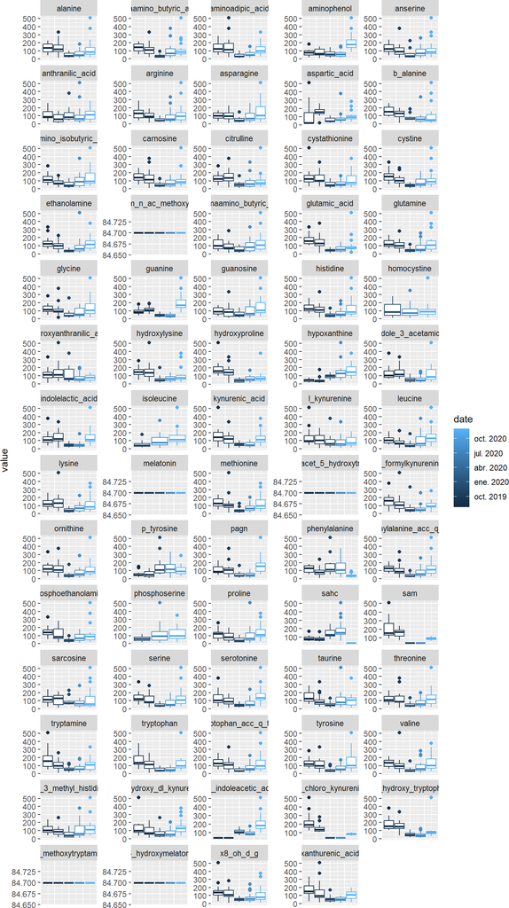

```r
metab_norm <- metab %>% dplyr::select(arginine:hypoxanthine) %>% as.matrix() %>%
  preprocessCore::normalize.quantiles() %>%
  as_tibble() %>%
  set_colnames(colnames(metab[-c(1:2)])) %>% bind_cols(metab[,c("code", "date")])

metab_norm %>%
pivot_longer(arginine:hypoxanthine, names_to="metabolites")  %>%
  ggplot (aes(group=date, y = value, colour=date)) + geom_boxplot() +
  facet_wrap(vars(metabolites), scales="free_y", ncol=5) +
  theme(axis.ticks.x = element_blank(), axis.text.x = element_blank())
```

Le us pre-process data. Let us start by looking at missing information

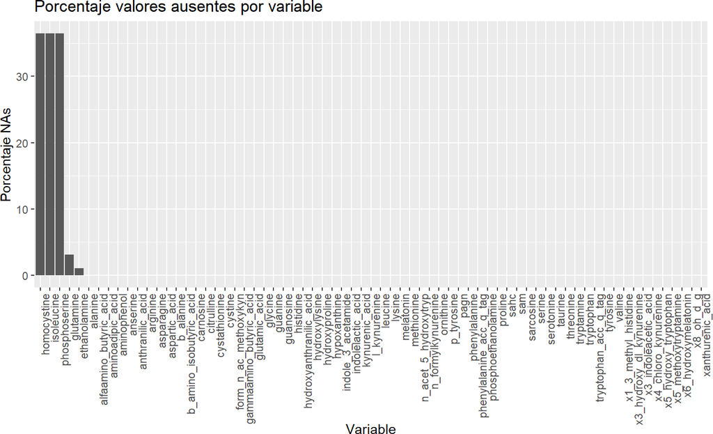

```r
metab_norm %>% pivot_longer(arginine:hypoxanthine, names_to="metabolites") %>%
  group_by(metabolites) %>%
  dplyr::summarize(porcentaje_NA = 100 * sum(is.na(value)) / length(value)) %>%
  ggplot(aes(x = reorder(metabolites, desc(porcentaje_NA)), y = porcentaje_NA)) +
    geom_col() +
    labs(title = "Porcentaje valores ausentes por variable",
         x = "Variable", y = "Porcentaje NAs") +
    theme(axis.text.x = element_text(angle = 90, hjust=1))
```

Now let us pre-process the data: impute missing, remove variables with low variability and scale data

```r
# create object recipe
metab_recipe <- recipe(code ~ ., data = metab) %>%
  step_rm(c("homocystine", "isoleucine", "phosphoserine", "code", "date")) %>%
  step_nzv(all_numeric_predictors()) %>%
  step_impute_knn(c("glutamine", "ethanolamine")) %>%
  step_normalize(all_numeric_predictors())
#  step_corr(all_numeric_predictors())
#  step_outliers_maha(all_numeric()) %>%
#  step_outliers_lookout(all_numeric(), -contains(r"(.outliers)"), -all_outcomes()) %>%
#  step_outliers_remove(contains(r"(.outliers)"))

metab_preproc <- prep(metab_recipe, training = metab) %>%
  bake(new_data = NULL) %>% bind_cols(metab[,c("code", "date")])
```

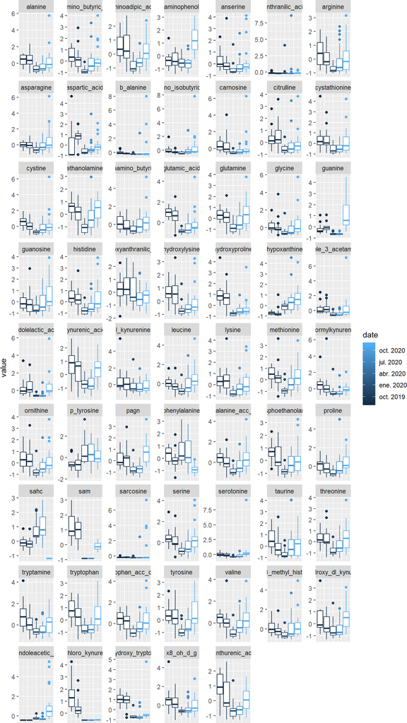

Figure 5: Metabolite data  
Data after pre-processing

```r
metab_preproc %>%
pivot_longer(arginine:hypoxanthine, names_to="metabolites")  %>%
  ggplot (aes(group=date, y = value, colour=date)) + geom_boxplot() +
  facet_wrap(vars(metabolites), scales="free_y", ncol=7) +
  theme(axis.ticks.x = element_blank(), axis.text.x = element_blank())
```

Let us add the data

```r
# add metabolome data to workload
fcbData.metab <- fcbData %>%
  left_join(metab_preproc, by = c("code" = "code",
                         "date" = "date")) %>%
  filter(!code%in%c("FCB24", "FCB1", "FCB2", "FCB19", "FCB22"))
```

Let us visualize the relationship between metabolites and injuries

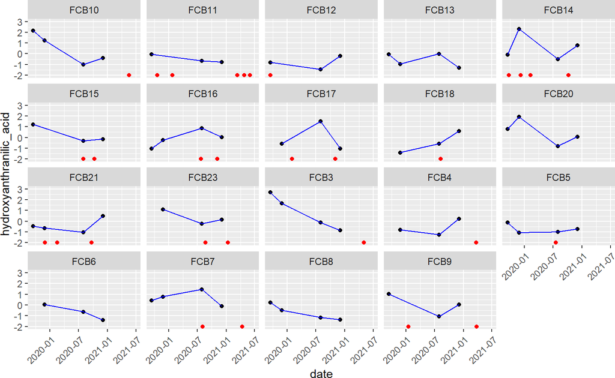

```r
fcbData.metab %>% group_by(code) %>%
  mutate(y = na.approx(hydroxyanthranilic_acid, na.rm=FALSE)) %>% ungroup() %>%
  ggplot(aes(x=date, y=hydroxyanthranilic_acid)) +
  geom_point() + geom_line(aes(x=date, y=y), col="blue") +
  geom_point(data=fcbData.metab%>%filter(injur==1), aes(x=date, y=-2), col="red") +
  ylim(-2,3) + theme(axis.text.x = element_text(angle = 45, vjust = 1, hjust=1)) +
  facet_wrap(~code)
```

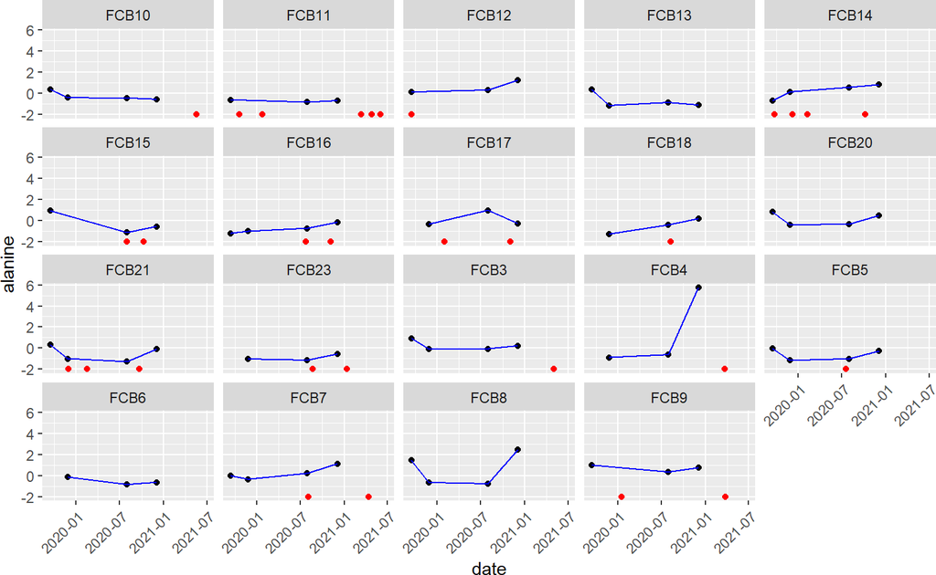

```r
fcbData.metab %>% group_by(code) %>%
  mutate(y = na.approx(alanine, na.rm=FALSE)) %>% ungroup() %>%
  ggplot(aes(x=date, y=alanine)) +
  geom_point() + geom_line(aes(x=date, y=y), col="blue") +
  geom_point(data=fcbData.metab%>%filter(injur==1), aes(x=date, y=-2), col="red") +
  theme(axis.text.x = element_text(angle = 45, vjust = 1, hjust=1)) +
  facet_wrap(~code)
```

Let us interpolate all metabolites

```r
fcbData.metab <- fcbData.metab %>% group_by(code) %>%
  mutate(across(arginine:hypoxanthine, ~na.approx(., na.rm=FALSE))) %>%
  ungroup()
```

Let us add data to counting process

```r
temp_cb <- create_crossbasis(fcbData.metab, pl_min_a_u_min)
data_cb_pl_metab <- temp_cb$cb
data_cp_metab <- temp_cb$data_cp


time_dep_metab <- fcbData.metab %>% filter(date%in%metab$date) %>%
    dplyr::select(code, Day, bmi, fat, n_injur, arginine:hypoxanthine)

data_cp_metab <- data_cp_metab %>% filter(code%in%time_dep_metab$code) %>%
  fuzzy_left_join(time_dep_metab,
                  by=c("code" = "code",
                       "enter" = "Day",
                       "exit" = "Day"),
                  match_fun = list(`==`, `<=`, `>`)) %>%
  rename (code = code.x) %>%
  group_by(code) %>%
  mutate(across(arginine:hypoxanthine, ~na.spline(.))) %>%
  fill(bmi:n_injur, .direction = "downup") %>%
  ungroup()


data_cp_metab <- data_cp_metab %>% left_join(gg.f.s, by = "code")  %>%
  # make dominant due to low numbers (only 1)
  mutate(rs1800255 = recode(rs1800255, "A/A" = "G/A"),
         rs240736 = droplevels(rs240736)) %>%
  mutate(across(starts_with("rs"), ~additive(snp(.))))
```

# 6 Data modelling

## 6.1 External load

Let us check baseline model

```r
baseline <- coxph(Surv(enter, exit, event) ~ poly(fat,2) +
                    frailty.gaussian(id),
                  data=data_cp,
                 y = FALSE, ties = "efron")
summary(baseline)
```

```
Call:
coxph(formula = Surv(enter, exit, event) ~ poly(fat, 2) + frailty.gaussian(id),
    data = data_cp, ties = "efron", y = FALSE)

  n= 894, number of events= 40

                     coef    se(coef) se2   Chisq DF  p
poly(fat, 2)1        0.07926 4.100    4.037 0.00  1.0 0.9800
poly(fat, 2)2        9.48951 3.668    3.611 6.69  1.0 0.0097
frailty.gaussian(id)                        0.52  0.5 0.2500

              exp(coef) exp(-coef) lower .95 upper .95
poly(fat, 2)1     1.082  9.238e-01 0.0003506      3343
poly(fat, 2)2 13220.344  7.564e-05 9.9854567  17503206

Iterations: 9 outer, 34 Newton-Raphson
     Variance of random effect= 0.01574848
Degrees of freedom for terms= 1.9 0.5
Concordance= 0.621  (se = 0.047 )
Likelihood ratio test= 7.74  on 2.43 df,   p=0.03
```

```r
anova(baseline)
```

```
Analysis of Deviance Table
 Cox model: response is Surv(enter, exit, event)
Terms added sequentially (first to last)

                      loglik  Chisq      Df Pr(>|Chi|)
NULL                 -126.29
poly(fat, 2)         -122.93 6.7200 2.00000    0.03473 *
frailty.gaussian(id) -122.42 1.0222 0.43278    0.12905
---
Signif. codes:  0 '***' 0.001 '**' 0.01 '*' 0.05 '.' 0.1 ' ' 1
```

```r
ii <- !is.na(l_cb$pl_min_a_u_min$cb[,1])
baseline.rm <- coxph(Surv(enter, exit, event) ~  frailty.gaussian(id) +
                       poly(fat,2),
                  data=data_cp[ii, ],
                 y = FALSE, ties = "efron")
summary(baseline.rm)
```

```
Call:
coxph(formula = Surv(enter, exit, event) ~ frailty.gaussian(id) +
    poly(fat, 2), data = data_cp[ii, ], ties = "efron", y = FALSE)

  n= 829, number of events= 35

                     coef  se(coef) se2   Chisq DF   p
frailty.gaussian(id)                      0.04  0.04 0.60
poly(fat, 2)1        1.616 4.229    4.225 0.15  1.00 0.70
poly(fat, 2)2        8.351 3.837    3.832 4.74  1.00 0.03

              exp(coef) exp(-coef) lower .95 upper .95
poly(fat, 2)1     5.032  0.1987205  0.001264     20040
poly(fat, 2)2  4232.529  0.0002363  2.294696   7806829

Iterations: 10 outer, 39 Newton-Raphson
     Variance of random effect= 0.001302083
Degrees of freedom for terms= 0 2
Concordance= 0.579  (se = 0.059 )
Likelihood ratio test= 5.78  on 2.03 df,   p=0.06
```

```r
anova(baseline.rm)
```

```
Analysis of Deviance Table
 Cox model: response is Surv(enter, exit, event)
Terms added sequentially (first to last)

                      loglik  Chisq     Df Pr(>|Chi|)
NULL                 -109.22
frailty.gaussian(id) -109.18 0.0859 1.0000    0.76943
poly(fat, 2)         -106.33 5.6947 1.0307    0.01788 *
---
Signif. codes:  0 '***' 0.001 '**' 0.01 '*' 0.05 '.' 0.1 ' ' 1
```

Let us fit the univariate models

```r
res_load <- l_cb %>% map (pluck(1)) %>%
  map(.,  ~ coxph(Surv(enter, exit, event) ~ .x + poly(fat, 2) +
                    frailty.gaussian(id),   data=data_cp,
                 y = FALSE, ties = "efron"))
```

Compute p-value

```r
p_load <- map_dbl(res_load, ~ anova(.x)[2,4])
final_res <- tibble(feature=names(res_load) , data="workload",
                    effect=NA, p_value=p_load)
kable(final_res, digits=c(0,0,2,4)) %>% kable_styling()
```

| feature | data | effect | p_value |
| --- | --- | --- | --- |
| duration_min | workload | NA | 0.0931 |
| dist_m | workload | NA | 0.3782 |
| dist_min_m_min | workload | NA | 0.2558 |
| rel_hsr_m | workload | NA | 0.1536 |
| rel_hsr_min_m_min | workload | NA | 0.3386 |
| hmld_m | workload | NA | 0.3027 |
| hmld_min_m_min | workload | NA | 0.0963 |
| acc_3_m_s2_min_count_min | workload | NA | 0.5761 |
| acc_3_m_s2_dist_m | workload | NA | 0.6181 |
| acc_3_m_s2_count | workload | NA | 0.6891 |
| dec_3_m_s2_min_count_min | workload | NA | 0.0940 |
| dec_3_m_s2_dist_m | workload | NA | 0.1377 |
| dec_3_m_s2_count | workload | NA | 0.0175 |
| pl_a_u | workload | NA | 0.3844 |
| pl_min_a_u_min | workload | NA | 0.0328 |

Now, let us visualize some results.

- This is for player load

```r
data_cb_pl <- create_crossbasis(fcbData, pl_min_a_u_min)$cb
mod_dnlm_pl <- coxph(Surv(enter, exit, event) ~ data_cb_pl + poly(fat,2) +
                    frailty.gaussian(id), data=data_cp,
                 y = FALSE, ties = "efron")
anova(mod_dnlm_pl)
```

```
Analysis of Deviance Table
 Cox model: response is Surv(enter, exit, event)
Terms added sequentially (first to last)

                      loglik   Chisq       Df Pr(>|Chi|)
NULL                 -109.22
data_cb_pl           -103.97 10.5034 4.000000    0.03275 *
poly(fat, 2)         -102.31  3.3073 2.000000    0.19135
frailty.gaussian(id) -102.28  0.0667 0.028774    0.04042 *
---
Signif. codes:  0 '***' 0.001 '**' 0.01 '*' 0.05 '.' 0.1 ' ' 1
```

Create predictions

```r
cuts <- seq(0, 4, .1 )
preds_pl <- crosspred(basis = data_cb_pl, mod_dnlm_pl,
                  at=cuts, cen = 0, ci.level = 0.90, cumul = TRUE)
```

3D-plot

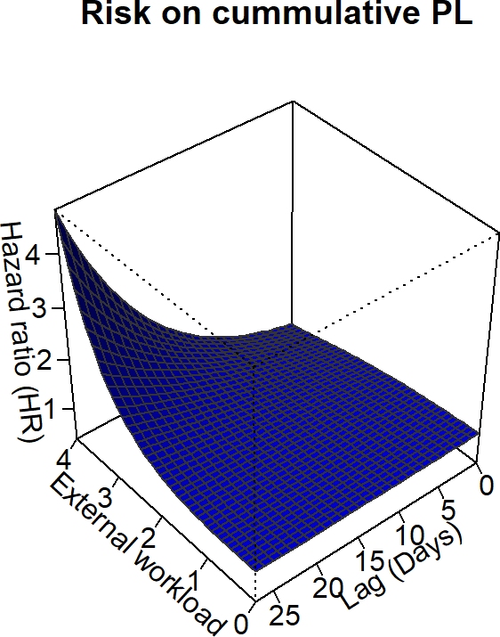

```r
plot3D_pred(preds_pl, xlab="External workload",
                       tit="Risk on cummulative PL")
```

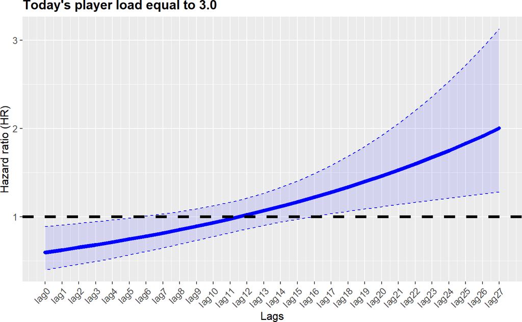

```r
k <- "3"
pp <- tibble(lag = c(colnames(preds_pl$matRRfit)), fit=c(preds_pl$matRRfit[k,]),
             lower = c(preds_pl$matRRlow[k,]), upper=c(preds_pl$matRRhigh[k,]),
             se.fit=c(preds_pl$matse[k,]), lag2=1:(ncol(preds_pl$matRRfit)))


pp %>%   ggplot(aes(x=lag2, y=fit)) +
  geom_point(col="blue") + geom_line(col="blue", size=2) +
  geom_ribbon(aes(ymin=lower, ymax=upper), linetype=2, fill="blue", col="blue", alpha=0.1) +
  scale_x_continuous(breaks = pp$lag2, labels=pp$lag) + xlab("Lags") +
  ylab("Hazard ratio (HR)") + geom_hline(yintercept=1, linetype="dashed", size=1.5) +
  ggtitle("Today's player load equal to 3.0") +
  theme(axis.text=element_text(size=10),
        axis.title=element_text(size=12),
        axis.text.x=element_text(angle=45, hjust=1),
        plot.title = element_text(size=14, face="bold"))
```

We can see how the risk changes for different training load

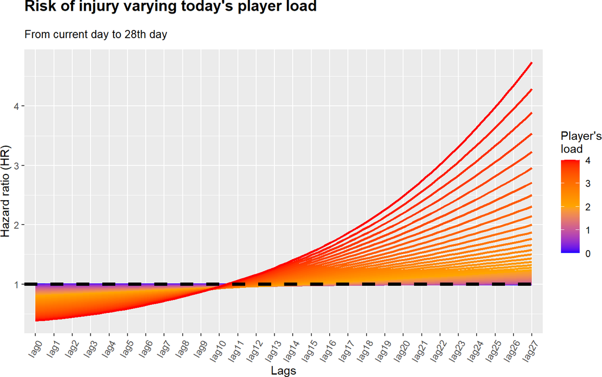

```r
pp <- preds_pl$matRRfit %>% as.data.frame() %>%
  tibble::rownames_to_column() %>% rename("workload" = "rowname") %>%
  pivot_longer(!workload, names_to="lags", values_to = "rr") %>%
  mutate(workload = as.numeric(workload)) %>%
  mutate(lags = as_factor(lags))


mid <- mean(pp$workload)
ggplot(pp, aes(lags, rr, group = workload, col=workload)) +
  stat_smooth(method="loess", formula = 'y~x', se = FALSE) +
  scale_color_gradient2(midpoint = mid, low = "blue", mid = "orange",
                        high = "red", space = "Lab",
                        name="Player's \nload") +
  ylab("Hazard ratio (HR)") + xlab("Lags") +
  ggtitle("Risk of injury varying today's player load",
          subtitle = "From current day to 28th day") +
  geom_hline(yintercept=1, linetype="dashed", size=1.5) +
  theme(
    plot.title = element_text(size = 14,
                              face = "bold",
                              color = "black"),
    plot.subtitle = element_text(size = 10,
                                 margin = ggplot2::margin(9,0,9,0),
                                 color = "black"),
    axis.text.x=element_text(angle=60, hjust=1))
```

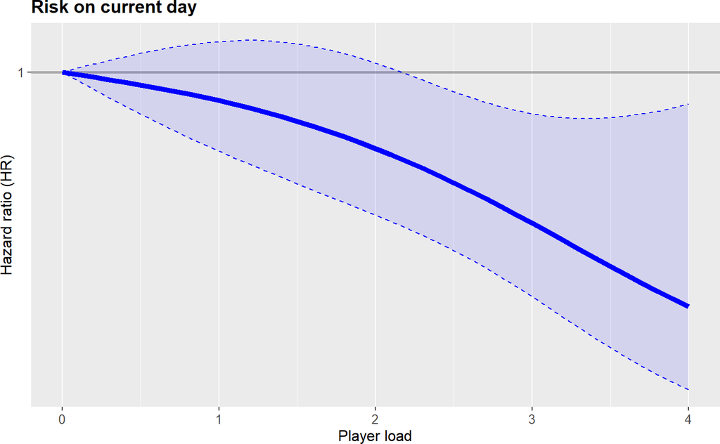

```r
lag_fixed <- "lag0"
colnumber <- which(colnames(preds_pl$matRRfit) == lag_fixed)
pp <- as_tibble(preds_pl$matRRfit[,colnumber]) %>%
  rename(coef = value) %>%
  mutate(load = preds_pl$predvar,
         lower = preds_pl$matRRlow[,colnumber],
         upper = preds_pl$matRRhigh[,colnumber])

pp %>% ggplot(aes(x = load, y = coef, group = 1)) +
  geom_hline(yintercept = 1, alpha = 0.3, size = 1) +
  geom_ribbon(aes(min = lower, max = upper),
              alpha = 0.1, linetype=2, fill = "blue", col = "blue") +
  geom_line(size = 2, color = "blue") +
  xlab("Player load") +
  ylab("Hazard ratio (HR)") + scale_y_continuous(breaks=c(1,2,3,4,5,10)) +
  ggtitle("Risk on current day") +
  theme(axis.text=element_text(size=10),
        axis.title=element_text(size=12),
        plot.title = element_text(size=14, face="bold"))
```

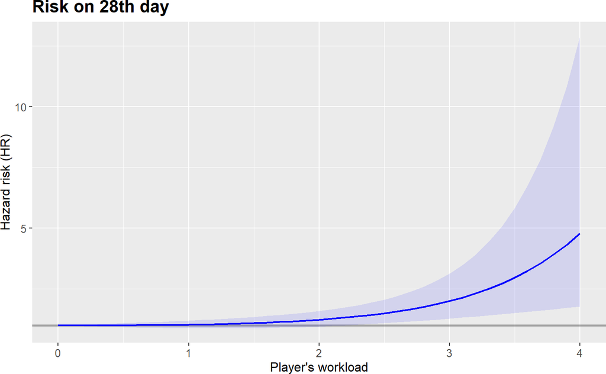

```r
lag_fixed <- "lag27"
colnumber <- which(colnames(preds_pl$matRRfit) == lag_fixed)
pp <- as_tibble(preds_pl$matRRfit[,colnumber]) %>%
  rename(coef = value) %>%
  mutate(load = preds_pl$predvar,
         lower = preds_pl$matRRlow[,colnumber],
         upper = preds_pl$matRRhigh[,colnumber])

pp %>% ggplot(aes(x = load, y = coef, group = 1)) +
  geom_hline(yintercept = 1, alpha = 0.3, size = 1) +
  geom_ribbon(aes(min = lower, max = upper),
              alpha = 0.1, linetype=2, fill = "blue") +
  geom_line(size = 0.75, color = "blue") +
  xlab("Player's workload") +
  ylab("Hazard risk (HR)") +
  ggtitle("Risk on 28th day") +
  theme(axis.text=element_text(size=10),
        axis.title=element_text(size=12),
        plot.title = element_text(size=16, face="bold"))
```

- This is for decelerations

```r
data_cb_dec <- create_crossbasis(fcbData, dec_3_m_s2_count)$cb
mod_dnlm_dec <- coxph(Surv(enter, exit, event) ~ data_cb_dec + poly(fat,2) +
                    frailty.gaussian(id), data=data_cp,
                 y = FALSE, ties = "efron")
anova(mod_dnlm_dec)
```

```
Analysis of Deviance Table
 Cox model: response is Surv(enter, exit, event)
Terms added sequentially (first to last)

                      loglik   Chisq       Df Pr(>|Chi|)
NULL                 -109.22
data_cb_dec          -103.23 11.9848 4.000000    0.01746 *
poly(fat, 2)         -101.61  3.2298 2.000000    0.19892
frailty.gaussian(id) -101.58  0.0596 0.026421    0.03854 *
---
Signif. codes:  0 '***' 0.001 '**' 0.01 '*' 0.05 '.' 0.1 ' ' 1
```

Create predictions

```r
cuts <- seq(0, 100, 10)
preds_dec <- crosspred(basis = data_cb_dec, mod_dnlm_dec,
                  at=cuts, cen = 0, cumul = TRUE, ci.level = 0.90)
```

3D-plot

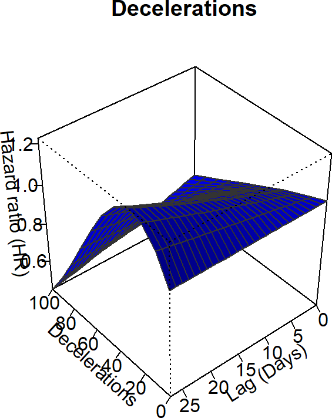

```r
plot3D_pred(preds_dec, xlab="Decelerations",
                       tit="Decelerations")
```

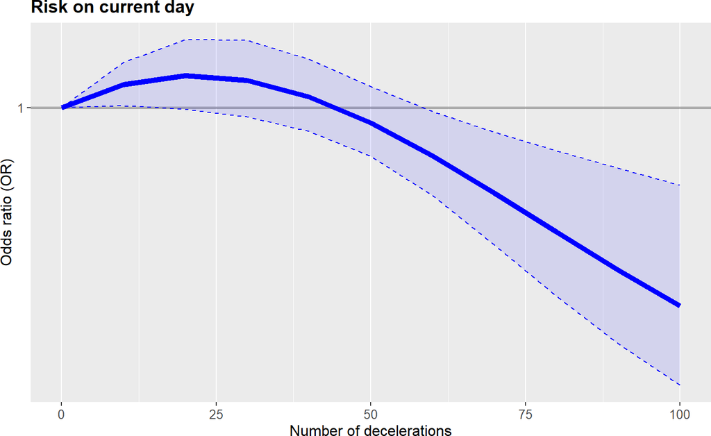

```r
lag_fixed <- "lag14"
colnumber <- which(colnames(preds_dec$matRRfit) == lag_fixed)
pp <- as_tibble(preds_dec$matRRfit[,colnumber]) %>%
  rename(coef = value) %>%
  mutate(load = preds_dec$predvar,
         lower = preds_dec$matRRlow[,colnumber],
         upper = preds_dec$matRRhigh[,colnumber])

pp %>% ggplot(aes(x = load, y = coef, group = 1)) +
  geom_hline(yintercept = 1, alpha = 0.3, size = 1) +
  geom_ribbon(aes(min = lower, max = upper),
              alpha = 0.1, linetype=2, fill = "blue", col = "blue") +
  geom_line(size = 2, color = "blue") +
  xlab("Number of decelerations") +
  ylab("Odds ratio (OR)") + scale_y_continuous(breaks=c(1,2,3,4,5,10)) +
  ggtitle("Risk on current day") +
  theme(axis.text=element_text(size=10),
        axis.title=element_text(size=12),
        plot.title = element_text(size=14, face="bold"))
```

- This is for high speed rate (HSR)

```r
data_cb_hsr <- create_crossbasis(fcbData, rel_hsr_m)$cb
mod_dnlm_hsr <- coxph(Surv(enter, exit, event) ~ data_cb_hsr + poly(fat,2) +
                    frailty.gaussian(id), data=data_cp,
                 y = FALSE, ties = "efron")
anova(mod_dnlm_hsr)
```

```
Analysis of Deviance Table
 Cox model: response is Surv(enter, exit, event)
Terms added sequentially (first to last)

                      loglik  Chisq       Df Pr(>|Chi|)
NULL                 -109.22
data_cb_hsr          -105.88 6.6841 4.000000    0.15355
poly(fat, 2)         -104.51 2.7334 2.000000    0.25495
frailty.gaussian(id) -104.48 0.0680 0.027553    0.03849 *
---
Signif. codes:  0 '***' 0.001 '**' 0.01 '*' 0.05 '.' 0.1 ' ' 1
```

Create predictions

```r
cuts <- seq(0, 40, 1)
preds_hsr <- crosspred(basis = data_cb_hsr, mod_dnlm_hsr,
                  at=cuts, cen = 0, cumul = TRUE)
```

3D-plot

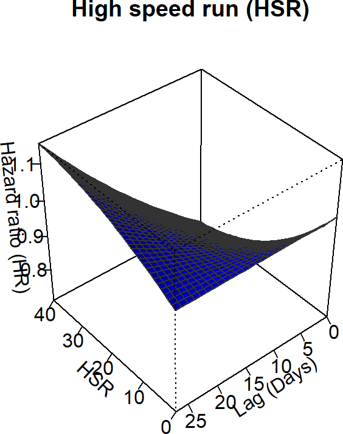

```r
plot3D_pred(preds_hsr, xlab="HSR",
            tit="High speed run (HSR)")
```

- This is for High Metabolic load distance

```r
data_cb_hmld <- create_crossbasis(fcbData, hmld_m)$cb
mod_dnlm_hmld <- coxph(Surv(enter, exit, event) ~ data_cb_hmld + poly(fat,2) +
                    frailty.gaussian(id), data=data_cp,
                 y = FALSE, ties = "efron")
anova(mod_dnlm_hmld)
```

```
Analysis of Deviance Table
 Cox model: response is Surv(enter, exit, event)
Terms added sequentially (first to last)

                      loglik  Chisq       Df Pr(>|Chi|)
NULL                 -109.22
data_cb_hmld         -106.79 4.8527 4.000000    0.30275
poly(fat, 2)         -104.86 3.8717 2.000000    0.14430
frailty.gaussian(id) -104.82 0.0684 0.027665    0.03857 *
---
Signif. codes:  0 '***' 0.001 '**' 0.01 '*' 0.05 '.' 0.1 ' ' 1
```

Create predictions

```r
cuts <- seq(0, 2000, 100)
preds_hmld <- crosspred(basis = data_cb_hmld, mod_dnlm_hmld,
                  at=cuts, cen = 0, cumul = TRUE)
```

3D-plot

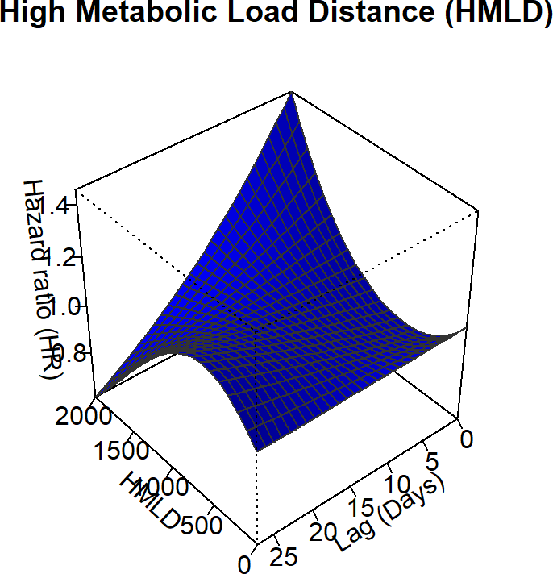

```r
plot3D_pred(preds_hmld, xlab="HMLD", tit="High Metabolic Load Distance (HMLD)")
```

- This is for accelerations

```r
data_cb_acc <- create_crossbasis(fcbData, acc_3_m_s2_dist_m)$cb
mod_dnlm_acc <- coxph(Surv(enter, exit, event) ~ data_cb_acc + poly(fat,2) +
                    frailty.gaussian(id), data=data_cp,
                 y = FALSE, ties = "efron")
anova(mod_dnlm_acc)
```

```
Analysis of Deviance Table
 Cox model: response is Surv(enter, exit, event)
Terms added sequentially (first to last)

                      loglik  Chisq       Df Pr(>|Chi|)
NULL                 -109.22
data_cb_acc          -107.89 2.6495 4.000000    0.61809
poly(fat, 2)         -105.46 4.8680 2.000000    0.08769 .
frailty.gaussian(id) -105.43 0.0692 0.027886    0.03871 *
---
Signif. codes:  0 '***' 0.001 '**' 0.01 '*' 0.05 '.' 0.1 ' ' 1
```

## 6.2 Genetics

Let us perform genetic association analyses assuming and additive model

```r
res_snp <- data_cp %>% dplyr::select(starts_with("rs")) %>%
  map(., ~ mod.SNP(.x))
res_snp_adj <- data_cp %>% dplyr::select(starts_with("rs")) %>%
  map(., ~mod.SNP.adj(.x))
res_snp_adj_dom <- data_cp %>% dplyr::select(starts_with("rs")) %>%
  map(., ~mod.SNP.adj.dom(.x))



p_snp <- res_snp %>% map_dbl(~ summary(.x)$coef[4,6])
p_snp_adj_add <- res_snp_adj %>% map_dbl(~ summary(.x)$coef[8,6])
p_snp_adj_dom <- res_snp_adj_dom %>% map_dbl(~ summary(.x)$coef[8,6])

effect_snp <- map_dbl(res_snp, ~ coef(.x)[3])
effect_snp_adj <- map_dbl(res_snp_adj, ~ coef(.x)[7])
effect_snp_dom <- map_dbl(res_snp_adj, ~ coef(.x)[7])
```

The SNPs that are statistically significant are

```r
sel_snp_adj_add <- names(which(p_snp_adj_add<0.05))
sel_snp_adj_add
```

```
[1] "rs699947"  "rs1799750" "rs9406328" "rs162502"  "rs4903399"
```

```r
sel_snp_adj_dom <- names(which(p_snp_adj_dom<0.05))
sel_snp_adj_dom
```

```
[1] "rs1799750" "rs516115"  "rs162502"  "rs4903399"
```

```r
sel_snp_adj <- unique(c(sel_snp_adj_add, sel_snp_adj_dom))
sel_snp_adj
```

```
[1] "rs699947"  "rs1799750" "rs9406328" "rs162502"  "rs4903399"
[6] "rs516115"
```

Let us add the results to the previous ones

```r
temp <- tibble(feature=sel_snp_adj , data="genetics",
               effect=exp(effect_snp[sel_snp_adj]),
               p_value=p_snp[sel_snp_adj],
               effect_adj=exp(effect_snp_adj[sel_snp_adj]),
               p_value_adj=p_snp_adj_add[sel_snp_adj])
final_res <- bind_rows(final_res, temp)
kable(final_res, digits=c(0,0,2,4,2,4)) %>% kable_styling()
```

| feature | data | effect | p_value | effect_adj | p_value_adj |
| --- | --- | --- | --- | --- | --- |
| duration_min | workload | NA | 0.0931 | NA | NA |
| dist_m | workload | NA | 0.3782 | NA | NA |
| dist_min_m_min | workload | NA | 0.2558 | NA | NA |
| rel_hsr_m | workload | NA | 0.1536 | NA | NA |
| rel_hsr_min_m_min | workload | NA | 0.3386 | NA | NA |
| hmld_m | workload | NA | 0.3027 | NA | NA |
| hmld_min_m_min | workload | NA | 0.0963 | NA | NA |
| acc_3_m_s2_min_count_min | workload | NA | 0.5761 | NA | NA |
| acc_3_m_s2_dist_m | workload | NA | 0.6181 | NA | NA |
| acc_3_m_s2_count | workload | NA | 0.6891 | NA | NA |
| dec_3_m_s2_min_count_min | workload | NA | 0.0940 | NA | NA |
| dec_3_m_s2_dist_m | workload | NA | 0.1377 | NA | NA |
| dec_3_m_s2_count | workload | NA | 0.0175 | NA | NA |
| pl_a_u | workload | NA | 0.3844 | NA | NA |
| pl_min_a_u_min | workload | NA | 0.0328 | NA | NA |
| rs699947 | genetics | 0.49 | 0.0141 | 0.49 | 0.0313 |
| rs1799750 | genetics | 0.49 | 0.0063 | 0.46 | 0.0078 |
| rs9406328 | genetics | 0.54 | 0.0583 | 0.46 | 0.0337 |
| rs162502 | genetics | 0.35 | 0.0222 | 0.38 | 0.0377 |
| rs4903399 | genetics | 0.47 | 0.0356 | 0.34 | 0.0150 |
| rs516115 | genetics | 0.62 | 0.0622 | 0.64 | 0.1013 |

These are the alleles and whether they are in HWE

```r
ss.geno[sel_snp_adj,]
```

```
          alleles major.allele.freq      HWE missing
rs699947      C/A              52.1 0.237091       0
rs1799750     A/B              50.0 0.682630       0
rs9406328     G/A              64.6 0.175267       0
rs162502      G/A              83.3 0.090139       0
rs4903399     C/T              75.0 0.596424       0
rs516115      A/G              62.5 0.193813       0
```

Here you have the confidence intervals

```r
map(res_snp_adj[sel_snp_adj], ~exp(confint(.x)[7,]))
```

```
$rs699947
    2.5 %    97.5 %
0.2535847 0.9375302

$rs1799750
    2.5 %    97.5 %
0.2603460 0.8150638

$rs9406328
    2.5 %    97.5 %
0.2279789 0.9422897

$rs162502
    2.5 %    97.5 %
0.1540589 0.9466185

$rs4903399
    2.5 %    97.5 %
0.1401626 0.8097314

$rs516115
    2.5 %    97.5 %
0.3782783 1.0906968
```

```r
map(res_snp_adj_dom[sel_snp_adj_dom], ~exp(confint(.x)[7,]))
```

```
$rs1799750
    2.5 %    97.5 %
0.2066099 0.9369234

$rs516115
    2.5 %    97.5 %
0.1856519 0.8856802

$rs162502
     2.5 %     97.5 %
0.07656343 0.87356999

$rs4903399
     2.5 %     97.5 %
0.09280098 0.67654658
```

Let us see the distribution of samples and injuries

```r
gg.f.s %>% dplyr::select(sel_snp_adj) %>% tbl_summary()
```

| **Characteristic** | **N = 24**<sup>1</sup> |
| --- | --- |
| rs699947 |  |
| C/C | 8 (33%) |
| C/A | 9 (38%) |
| A/A | 7 (29%) |
| rs1799750 |  |
| A/A | 5 (21%) |
| A/B | 14 (58%) |
| B/B | 5 (21%) |
| rs9406328 |  |
| G/G | 8 (33%) |
| G/A | 15 (62%) |
| A/A | 1 (4.2%) |
| rs162502 |  |
| G/G | 18 (75%) |
| G/A | 4 (17%) |
| A/A | 2 (8.3%) |
| rs4903399 |  |
| C/C | 14 (58%) |
| T/C | 8 (33%) |
| T/T | 2 (8.3%) |
| rs516115 |  |
| A/A | 11 (46%) |
| G/A | 8 (33%) |
| G/G | 5 (21%) |

<sup>1</sup> n (%)

```r
data_cp %>% filter(event == 1) %>%
  dplyr::select(sel_snp_adj) %>% tbl_summary()
```

| **Characteristic** | **N = 40**<sup>1</sup> |
| --- | --- |
| rs699947 |  |
| 0 | 19 (48%) |
| 1 | 12 (30%) |
| 2 | 9 (22%) |
| rs1799750 |  |
| 0 | 12 (30%) |
| 1 | 26 (65%) |
| 2 | 2 (5.0%) |
| rs9406328 | 25 (62%) |
| rs162502 |  |
| 0 | 37 (92%) |
| 1 | 2 (5.0%) |
| 2 | 1 (2.5%) |
| rs4903399 |  |
| 0 | 27 (68%) |
| 1 | 12 (30%) |
| 2 | 1 (2.5%) |
| rs516115 |  |
| 0 | 27 (68%) |
| 1 | 7 (18%) |
| 2 | 6 (15%) |

<sup>1</sup> n (%)

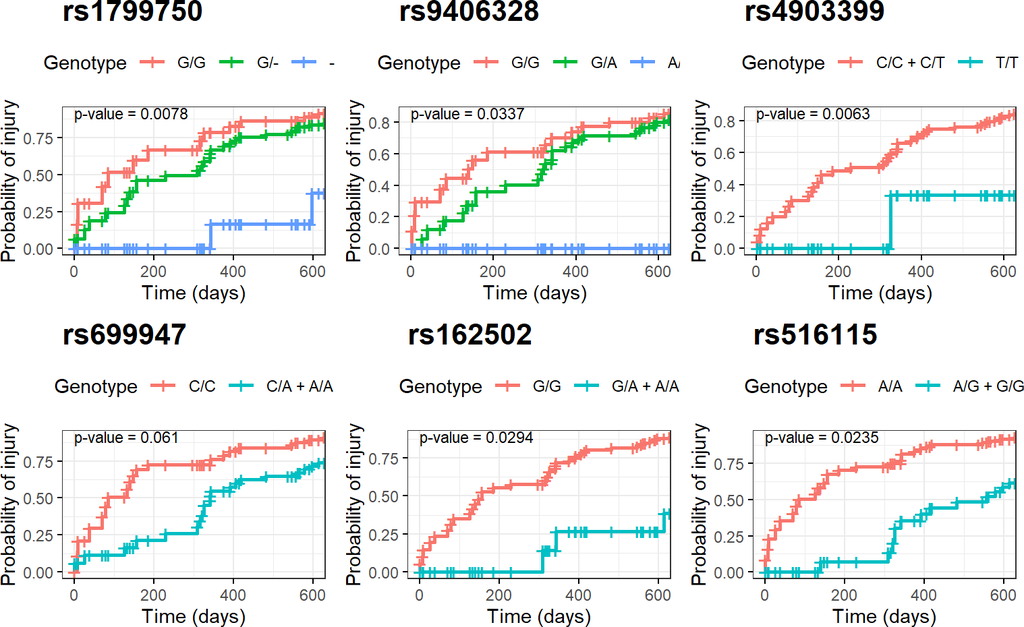

```r
p1 <- plotKM(rs1799750, lab=c("G/G", "G/-", "-/-"), p = p_snp_adj_add["rs1799750"]) +
  ggtitle("rs1799750")
p2 <- plotKM(rs699947, lab=c("C/C", "C/A + A/A"), p = p_snp_adj_dom["rs699947"], dominant =TRUE) +
  ggtitle("rs699947")
p3 <- plotKM(rs9406328, lab=c("G/G", "G/A", "A/A"), p = p_snp_adj_add["rs9406328"]) +
  ggtitle("rs9406328")
p4 <- plotKM(rs162502, lab=c("G/G", "G/A + A/A"), p = p_snp_adj_dom["rs162502"], dominant = TRUE) +
  ggtitle("rs162502")
p5 <- plotKM(rs4903399, lab=c("C/C + C/T", "T/T"), p = p_snp_adj_dom["rs4903399"], recessive = TRUE) +
  ggtitle("rs4903399")
p6 <- plotKM(rs516115, lab=c("A/A", "A/G + G/G"), p = p_snp_adj_dom["rs516115"], dominant = TRUE) +
  ggtitle("rs516115")

arrange_ggsurvplots(list(p1,p2,p3,p4, p5, p6), ncol = 3, nrow = 2)
```

Let us create a polygenic risk score

```r
final_snp <- step(update(res_snp_adj$rs1800896, ~. - additive(snp) +
                           rs699947 + rs4903399 + rs1799750 +  rs9406328 + rs162502 +
                           rs516115),
                  scope = list(lower=as.formula(.~data_cb_pl+frailty.gaussian(id))),
              trace = FALSE)
summary(final_snp)
```

```
Call:
coxph(formula = Surv(enter, exit, event) ~ poly(fat, 2) + data_cb_pl +
    frailty.gaussian(id) + rs699947 + rs4903399, data = data_cp,
    ties = "efron", y = FALSE)

  n= 829, number of events= 35
   (65 observations deleted due to missingness)

                     coef    se(coef) se2     Chisq DF   p
poly(fat, 2)1        10.4299 7.22188  7.21602 2.09  1.00 0.150
poly(fat, 2)2        11.0555 4.84359  4.83806 5.21  1.00 0.022
data_cb_plv1.l1      -1.2882 0.63358  0.63352 4.13  1.00 0.042
data_cb_plv1.l2       0.1141 0.04532  0.04532 6.34  1.00 0.012
data_cb_plv2.l1      -1.5625 1.04726  1.04723 2.23  1.00 0.140
data_cb_plv2.l2       0.1512 0.07139  0.07139 4.48  1.00 0.034
frailty.gaussian(id)                          0.01  0.03 0.690
rs699947             -0.8010 0.36482  0.36456 4.82  1.00 0.028
rs4903399            -1.0360 0.42992  0.42961 5.81  1.00 0.016

                exp(coef) exp(-coef) lower .95 upper .95
poly(fat, 2)1   3.386e+04  2.954e-05   0.02412 4.753e+10
poly(fat, 2)2   6.329e+04  1.580e-05   4.76953 8.399e+08
data_cb_plv1.l1 2.758e-01  3.626e+00   0.07966 9.547e-01
data_cb_plv1.l2 1.121e+00  8.922e-01   1.02559 1.225e+00
data_cb_plv2.l1 2.096e-01  4.771e+00   0.02691 1.632e+00
data_cb_plv2.l2 1.163e+00  8.597e-01   1.01132 1.338e+00
rs699947        4.489e-01  2.228e+00   0.21958 9.176e-01
rs4903399       3.549e-01  2.818e+00   0.15279 8.241e-01

Iterations: 10 outer, 35 Newton-Raphson
     Variance of random effect= 0.001302083
Degrees of freedom for terms= 2 4 0 1 1
Concordance= 0.751  (se = 0.042 )
Likelihood ratio test= 26.89  on 8.02 df,   p=7e-04
```

```r
sel <- sel_snp_adj
effect <- effect_snp_adj[sel]
pos <- which(colnames(data_cp) %in% sel)
score.nw <- PredictABEL::riskScore(effect*-1, data_cp, pos, "unweighted")

final_snp_score_nw <- coxph(Surv(enter, exit, event) ~ data_cb_pl + poly(fat,2) +
                          frailty.gaussian(id) + score.nw, data=data_cp,
                        y = FALSE, ties = "efron")

km_snp_score_nw <- survfit(Surv(enter, exit, event) ~ cut(score.nw, c(-Inf, 3, 5, Inf)), data=data_cp)

plot_score <- survminer::ggsurvplot(km_snp_score_nw,
        legend.labs = c("0-3", "4-5", "6+"),
        fun = "event",
        legend = "right",
        ggtheme = theme(axis.title = element_text(size=11)),
                  plot.title=element_text(size=12),
                  plot.subtitle=element_text(size=10))  +
  ylab("Probability of injury") +
  xlab ("Time (days)") +
  guides(
    fill = guide_legend(title = 'Genetic \nScore'),
    color = guide_legend(title = 'Genetic \n Score')
  )

  plot_score$plot <- plot_score$plot + ylim(0,1) +
    annotate("text", x=0, y=Inf,
             label = paste("p genetic score =",
                           formatC(summary(final_snp_score_nw)$coef[8,6],2)),
             hjust=0, vjust=1, size=3)

plot_score <- plot_score +
  ggtitle("Injury risk - genetics",
          subtitle = "Risk according to number \nof protective alleles")
```

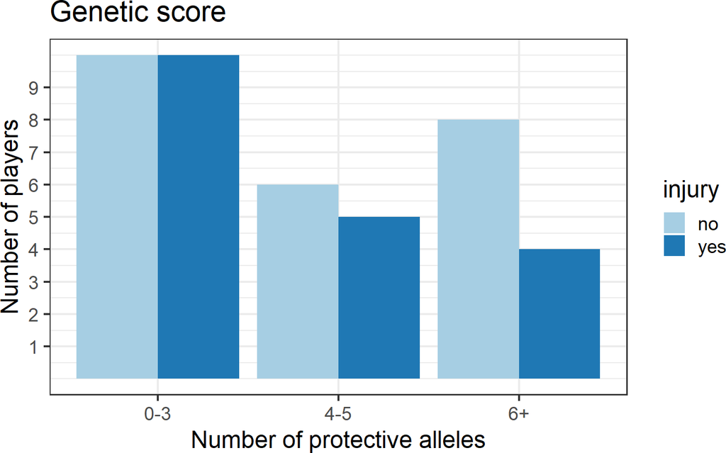

```r
plot_score_n <- data_cp %>% mutate(gs=cut(score.nw, c(-Inf, 3, 5, Inf), label=c('0-3', '4-5', '6+'))) %>%
  distinct(id, event, gs) %>%
  mutate(injury=factor(event, labels = c("no", "yes"))) %>%
  group_by(gs, injury) %>% summarize(counts=n()) %>%
  ggplot(aes(x = gs, y =counts, fill=injury)) +
  geom_bar(stat='identity', position = 'dodge') +
  scale_fill_brewer(type="qual", palette="Paired") +
  ylab("Number of players") +
  xlab("Number of protective alleles") +
  scale_y_continuous(breaks=1:9) +
  ggtitle("Genetic score")

plot_score_n + theme_bw(base_size = 18)
```

## 6.3 Metabolome

Let us perform metabolome data analysis

```r
res_metabo <- data_cp_metab %>%
  dplyr::select(arginine:hypoxanthine) %>%
  map(., ~mod.metabo(.))


res_metabo_adj <- data_cp_metab %>%
  dplyr::select(arginine:hypoxanthine) %>%
  map(., ~mod.metabo.adj(.))


p_metabo <- res_metabo %>% map_dbl(~ anova(.x)[2,4])
p_metabo_adj <- res_metabo_adj %>% map_dbl(~ anova(.x)[2,4])

effect_metabo <- map_dbl(res_metabo, ~ coef(.x)[1])
effect_metabo_adj <- map_dbl(res_metabo_adj, ~ coef(.x)[1])
```

The metabolites that are statistically significant are

```r
sel_metabo <- names(which(p_metabo<0.05))
sel_metabo
```

```
[1] "serotonine"
```

```r
sel_metabo_adj <- names(which(p_metabo_adj<0.05))
sel_metabo_adj
```

```
[1] "b_alanine"             "serotonine"
[3] "x5_hydroxy_tryptophan"
```

Let us add the results to the previous ones

```r
temp <- tibble(feature=sel_metabo_adj , data="metabolome",
               effect=effect_metabo[sel_metabo_adj],
               p_value=p_metabo[sel_metabo_adj],
               effect_adj=effect_metabo_adj[sel_metabo_adj],
               p_value_adj=p_metabo_adj[sel_metabo_adj])
final_res <- bind_rows(final_res, temp)
kable(final_res, digits=c(0,0,2,4,2,4)) %>% kable_styling()
```

| feature | data | effect | p_value | effect_adj | p_value_adj |
| --- | --- | --- | --- | --- | --- |
| duration_min | workload | NA | 0.0931 | NA | NA |
| dist_m | workload | NA | 0.3782 | NA | NA |
| dist_min_m_min | workload | NA | 0.2558 | NA | NA |
| rel_hsr_m | workload | NA | 0.1536 | NA | NA |
| rel_hsr_min_m_min | workload | NA | 0.3386 | NA | NA |
| hmld_m | workload | NA | 0.3027 | NA | NA |
| hmld_min_m_min | workload | NA | 0.0963 | NA | NA |
| acc_3_m_s2_min_count_min | workload | NA | 0.5761 | NA | NA |
| acc_3_m_s2_dist_m | workload | NA | 0.6181 | NA | NA |
| acc_3_m_s2_count | workload | NA | 0.6891 | NA | NA |
| dec_3_m_s2_min_count_min | workload | NA | 0.0940 | NA | NA |
| dec_3_m_s2_dist_m | workload | NA | 0.1377 | NA | NA |
| dec_3_m_s2_count | workload | NA | 0.0175 | NA | NA |
| pl_a_u | workload | NA | 0.3844 | NA | NA |
| pl_min_a_u_min | workload | NA | 0.0328 | NA | NA |
| rs699947 | genetics | 0.49 | 0.0141 | 0.49 | 0.0313 |
| rs1799750 | genetics | 0.49 | 0.0063 | 0.46 | 0.0078 |
| rs9406328 | genetics | 0.54 | 0.0583 | 0.46 | 0.0337 |
| rs162502 | genetics | 0.35 | 0.0222 | 0.38 | 0.0377 |
| rs4903399 | genetics | 0.47 | 0.0356 | 0.34 | 0.0150 |
| rs516115 | genetics | 0.62 | 0.0622 | 0.64 | 0.1013 |
| b_alanine | metabolome | -0.20 | 0.0551 | -0.24 | 0.0455 |
| serotonine | metabolome | 0.03 | 0.0354 | 0.04 | 0.0252 |
| x5_hydroxy_tryptophan | metabolome | 0.03 | 0.0698 | 0.05 | 0.0373 |

```r
write.table(final_res, file="final_res.txt", sep="\t",
            quote = FALSE, row.names=FALSE)
```

Let us visualize the results

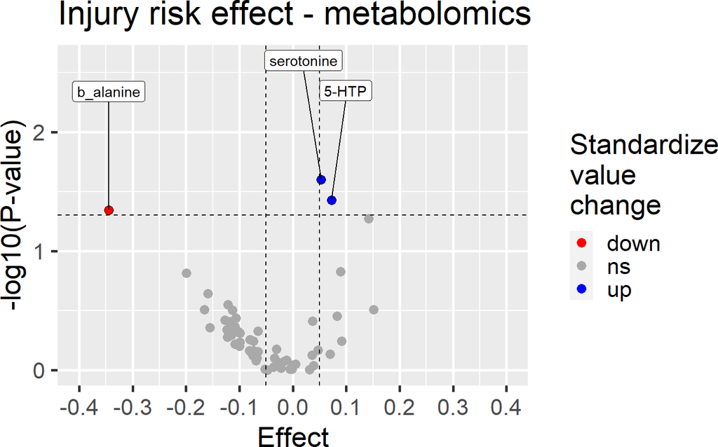

```r
library(ggrepel)
de <- data.frame(lab = names(p_metabo_adj),
                 fold_change = exp(effect_metabo_adj),
                 adj_p_val = p_metabo_adj,
                 de = ifelse(p_metabo_adj<0.05, "yes", "no"))

de$lab[de$lab=="x5_hydroxy_tryptophan"] <- "5-HTP"
rownames(de)[de$lab=="x5_hydroxy_tryptophan"] <- "5-HTP"


de <- de %>%
  mutate(gene_type = case_when(fold_change >= 1 & adj_p_val <= 0.05 ~ "up",
                               fold_change <= 1 & adj_p_val <= 0.05 ~ "down",
                               TRUE ~ "ns"))

cols <- c("up" = "blue", "down" = "red", "ns" = "darkgrey")
sizes <- c("up" = 2, "down" = 2, "ns" = 1)
alphas <- c("up" = 1, "down" = 1, "ns" = 0.5)

sig_il_genes <- de %>%
  filter(lab %in% c("b_alanine", "serotonine", "5-HTP"))


up_il_genes <- de %>%
  filter(lab == "b_alanine")

down_il_genes <- de %>%
  filter(lab %in% c("serotonine", "5-HTP"))


plot_metab <- ggplot(data = de,
                     aes(x = log2(fold_change),
                         y = -log10(adj_p_val))) +
  geom_point(aes(colour = gene_type),
             shape = 16,
             size = 3) +
  geom_point(data = up_il_genes,
             shape = 21,
             size = 3,
             fill = "red",
             colour = "black") +
  geom_point(data = down_il_genes,
             shape = 21,
             size = 3,
             fill = "blue",
             colour = "black") +
  geom_hline(yintercept = -log10(0.05),
             linetype = "dashed") +
  geom_vline(xintercept = c(-0.05, 0.05),
             linetype = "dashed") +
  geom_label_repel(data = sig_il_genes,
                   aes(label = lab),
                   force = 2,
                   nudge_y = 1) +
  scale_colour_manual(values = cols) +
  scale_x_continuous(breaks = c(seq(-.5, .5, .1)),
                     limits = c(-.4, .4)) +
  labs(title = "Injury risk effect - metabolomics",
       x = "Effect",
       y = "-log10(P-value)",
       colour = "Standardize \nvalue \nchange")

plot_metab + theme_grey(base_size = 21)
```

Let us create a multivariate model

```r
model_metabo <- step(update(res_metabo_adj$arginine, ~. - x + b_alanine +
                            serotonine + x5_hydroxy_tryptophan),
                     scope = list(lower=as.formula(.~data_cb_pl_metab)))
```

```
Start:  AIC=175.62
Surv(enter, exit, event) ~ poly(fat, 2) + data_cb_pl_metab +
    frailty.gaussian(id) + b_alanine + serotonine + x5_hydroxy_tryptophan

                              Df    AIC
- serotonine            1.000409 173.91
- x5_hydroxy_tryptophan 1.000864 173.98
- b_alanine             0.997402 175.24
<none>                           175.62
- frailty.gaussian(id)  0.016585 175.62
- poly(fat, 2)          1.988650 176.12

Step:  AIC=173.91
Surv(enter, exit, event) ~ poly(fat, 2) + data_cb_pl_metab +
    frailty.gaussian(id) + b_alanine + x5_hydroxy_tryptophan

                              Df    AIC
- x5_hydroxy_tryptophan 0.995961 172.00
- b_alanine             0.996825 173.71
- frailty.gaussian(id)  0.016176 173.91
<none>                           173.91
- poly(fat, 2)          1.988170 175.05

Step:  AIC=172
Surv(enter, exit, event) ~ poly(fat, 2) + data_cb_pl_metab +
    frailty.gaussian(id) + b_alanine

                             Df    AIC
- frailty.gaussian(id) 0.020214 171.99
<none>                          172.00
- b_alanine            0.999850 173.27
- poly(fat, 2)         1.989396 173.84

Step:  AIC=171.99
Surv(enter, exit, event) ~ poly(fat, 2) + data_cb_pl_metab +
    b_alanine

               Df    AIC
<none>            171.99
- b_alanine     1 173.26
- poly(fat, 2)  2 173.83
```

```r
summary(model_metabo)
```

```
Call:
coxph(formula = Surv(enter, exit, event) ~ poly(fat, 2) + data_cb_pl_metab +
    b_alanine, data = data_cp_metab, ties = "efron", y = FALSE)

  n= 576, number of events= 29
   (16 observations deleted due to missingness)

                            coef  exp(coef)   se(coef)      z
poly(fat, 2)1           -5.76020    0.00315    4.18299 -1.377
poly(fat, 2)2            8.37275 4327.52068    4.38049  1.911
data_cb_pl_metabv1.l1   -0.51283    0.59880    0.69224 -0.741
data_cb_pl_metabv1.l2    0.03857    1.03932    0.05783  0.667
data_cb_pl_metabv2.l1    0.15791    1.17107    1.08549  0.145
data_cb_pl_metabv2.l2   -0.02922    0.97120    0.08778 -0.333
b_alanine               -0.23910    0.78733    0.15057 -1.588
                      Pr(>|z|)
poly(fat, 2)1            0.168
poly(fat, 2)2            0.056 .
data_cb_pl_metabv1.l1    0.459
data_cb_pl_metabv1.l2    0.505
data_cb_pl_metabv2.l1    0.884
data_cb_pl_metabv2.l2    0.739
b_alanine                0.112
---
Signif. codes:  0 '***' 0.001 '**' 0.01 '*' 0.05 '.' 0.1 ' ' 1

                      exp(coef) exp(-coef) lower .95 upper .95
poly(fat, 2)1         3.150e-03  3.174e+02 8.666e-07 1.145e+01
poly(fat, 2)2         4.328e+03  2.311e-04 8.083e-01 2.317e+07
data_cb_pl_metabv1.l1 5.988e-01  1.670e+00 1.542e-01 2.326e+00
data_cb_pl_metabv1.l2 1.039e+00  9.622e-01 9.279e-01 1.164e+00
data_cb_pl_metabv2.l1 1.171e+00  8.539e-01 1.395e-01 9.830e+00
data_cb_pl_metabv2.l2 9.712e-01  1.030e+00 8.177e-01 1.154e+00
b_alanine             7.873e-01  1.270e+00 5.861e-01 1.058e+00

Concordance= 0.672  (se = 0.058 )
Likelihood ratio test= 14.39  on 7 df,   p=0.04
Wald test            = 13.59  on 7 df,   p=0.06
Score (logrank) test = 13.28  on 7 df,   p=0.07
```

## 6.4 Final model

Let us estimate a multi-modal predictive model

```r
model_final <-coxph(Surv(enter, exit, event) ~ data_cb_pl_metab   + poly(fat,2) +
                  rs699947 + rs1799750 + rs9406328 + rs162502 + rs4903399 + rs516115 +
            b_alanine + serotonine +
            x5_hydroxy_tryptophan +
        frailty.gaussian(id), data=data_cp_metab,
      y = FALSE, ties = "efron")
summary(model_final)
```

```
Call:
coxph(formula = Surv(enter, exit, event) ~ data_cb_pl_metab +
    poly(fat, 2) + rs699947 + rs1799750 + rs9406328 + rs162502 +
    rs4903399 + rs516115 + b_alanine + serotonine + x5_hydroxy_tryptophan +
    frailty.gaussian(id), data = data_cp_metab, ties = "efron",
    y = FALSE)

  n= 576, number of events= 29
   (16 observations deleted due to missingness)

                      coef     se(coef) se2     Chisq DF   p
data_cb_pl_metabv1.l1 -0.61604 0.74945  0.74945 0.68  1.00 0.41
data_cb_pl_metabv1.l2  0.04445 0.06517  0.06517 0.47  1.00 0.50
data_cb_pl_metabv2.l1 -0.02545 1.16819  1.16817 0.00  1.00 0.98
data_cb_pl_metabv2.l2 -0.01117 0.09895  0.09895 0.01  1.00 0.91
poly(fat, 2)1          7.76508 8.95094  8.94432 0.75  1.00 0.39
poly(fat, 2)2          8.36561 6.14849  6.14079 1.85  1.00 0.17
rs699947              -0.75003 0.48643  0.48605 2.38  1.00 0.12
rs1799750             -0.44508 0.51020  0.50977 0.76  1.00 0.38
rs9406328             -0.16538 0.50855  0.50806 0.11  1.00 0.75
rs162502              -1.33736 0.94728  0.94699 1.99  1.00 0.16
rs4903399             -0.01851 0.49219  0.49183 0.00  1.00 0.97
rs516115               0.02190 0.41134  0.41101 0.00  1.00 0.96
b_alanine             -0.18694 0.33438  0.33419 0.31  1.00 0.58
serotonine             0.23353 0.15167  0.15165 2.37  1.00 0.12
x5_hydroxy_tryptophan -0.33297 0.22311  0.22311 2.23  1.00 0.14
frailty.gaussian(id)                            0.01  0.01 0.73

                      exp(coef) exp(-coef) lower .95 upper .95
data_cb_pl_metabv1.l1    0.5401  1.8515721 1.243e-01 2.346e+00
data_cb_pl_metabv1.l2    1.0455  0.9565238 9.201e-01 1.188e+00
data_cb_pl_metabv2.l1    0.9749  1.0257763 9.876e-02 9.623e+00
data_cb_pl_metabv2.l2    0.9889  1.0112300 8.146e-01 1.201e+00
poly(fat, 2)1         2356.8529  0.0004243 5.666e-05 9.804e+10
poly(fat, 2)2         4296.7258  0.0002327 2.509e-02 7.358e+08
rs699947                 0.4724  2.1170684 1.821e-01 1.226e+00
rs1799750                0.6408  1.5606226 2.357e-01 1.742e+00
rs9406328                0.8476  1.1798469 3.128e-01 2.296e+00
rs162502                 0.2625  3.8089603 4.101e-02 1.681e+00
rs4903399                0.9817  1.0186820 3.741e-01 2.576e+00
rs516115                 1.0221  0.9783426 4.564e-01 2.289e+00
b_alanine                0.8295  1.2055606 4.307e-01 1.597e+00
serotonine               1.2631  0.7917332 9.383e-01 1.700e+00
x5_hydroxy_tryptophan    0.7168  1.3951098 4.629e-01 1.110e+00

Iterations: 10 outer, 43 Newton-Raphson
     Variance of random effect= 0.001302083
Degrees of freedom for terms= 4 2 1 1 1 1 1 1 1 1 1 0
Concordance= 0.75  (se = 0.042 )
Likelihood ratio test= 26.53  on 15 df,   p=0.03
```

# 7 Final results

Let us compare C-index for each model. First let us compute the leave-one-out cross-validation estimation

```r
colnames(data_cb_pl_metab) <- paste0("pl_", colnames(data_cb_pl_metab))
o <- complete.cases(data_cb_pl_metab)
data_cp_ok <- data_cp_metab %>% filter(o) %>%
  bind_cols(data_cb_pl_metab[o,])

ids <- unique(data_cp_ok$code)
n <- length(ids)

c_index <- list()

loo_models <- vector(mode = "list", length = n)
for(i in 1:n){
  df_tmp <- filter(data_cp_ok, code!=ids[i])
  mod <- coxph(Surv(enter, exit, event) ~
                 pl_v1.l1 + pl_v1.l2 + pl_v2.l1 + pl_v2.l2 +
                 poly(fat, 2) + frailty.gaussian(id),
               data = df_tmp,
               y = FALSE, ties = "efron")

  loo_models[[i]] <- mod
}

c_index[[1]] <- map(loo_models, ~ summary(.)$concordance[1]) %>%
  bind_cols(
    .name_repair = ~ vctrs::vec_as_names(
      ..., repair = "unique", quiet = TRUE)) %>%
  rowMeans() %>% round(3)*100



loo_models <- vector(mode = "list", length = n)
for(i in 1:n){
  df_tmp <- filter(data_cp_ok, code!=ids[i])
  mod <- coxph(Surv(enter, exit, event) ~
                 pl_v1.l1 + pl_v1.l2 + pl_v2.l1 + pl_v2.l2 +
                 poly(fat, 2) +
                 rs699947 + rs1799750 + rs9406328 +
                 rs162502 + rs4903399 + rs516115 +
                 frailty.gamma(id),
               data = df_tmp,
               y = FALSE, ties = "efron")

  loo_models[[i]] <- mod
}

c_index[[2]] <- map(loo_models, ~ summary(.)$concordance[1]) %>%
  bind_cols(
    .name_repair = ~ vctrs::vec_as_names(
      ..., repair = "unique", quiet = TRUE)) %>%
  rowMeans() %>% round(3)*100



loo_models <- vector(mode = "list", length = n)
for(i in 1:n){
  df_tmp <- filter(data_cp_ok, code!=ids[i])
  mod <- coxph(Surv(enter, exit, event) ~
                 pl_v1.l1 + pl_v1.l2 + pl_v2.l1 + pl_v2.l2 +
                 poly(fat, 2) +
                 b_alanine + serotonine + x5_hydroxy_tryptophan +
                 frailty.gamma(id),
               data = df_tmp,
               y = FALSE, ties = "efron")

  loo_models[[i]] <- mod
}

c_index[[3]] <- map(loo_models, ~ summary(.)$concordance[1]) %>%
  bind_cols(
    .name_repair = ~ vctrs::vec_as_names(
      ..., repair = "unique", quiet = TRUE)) %>%
  rowMeans() %>% round(3)*100



loo_models <- vector(mode = "list", length = n)
for(i in 1:n){
  df_tmp <- filter(data_cp_ok, code!=ids[i])
  mod <- coxph(Surv(enter, exit, event) ~
                 pl_v1.l1 + pl_v1.l2 + pl_v2.l1 + pl_v2.l2 +
                 poly(fat, 2) +
                 rs699947 + rs1799750 + rs9406328 +
                 rs162502 + rs4903399 + rs516115 +
                 b_alanine + serotonine + x5_hydroxy_tryptophan +
                 frailty.gamma(id),
               data = df_tmp,
               y = FALSE, ties = "efron")

  loo_models[[i]] <- mod
}

c_index[[4]] <- map(loo_models, ~ summary(.)$concordance[1]) %>%
  bind_cols(
    .name_repair = ~ vctrs::vec_as_names(
      ..., repair = "unique", quiet = TRUE)) %>%
  rowMeans() %>% round(3)*100
```

Then, let us create the plot

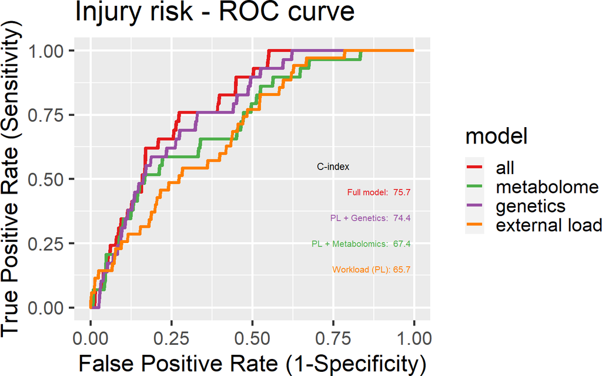

```r
my_palette = c(brewer.pal(5, "Set1")[c(1,3,4,5)], brewer.pal(5, "Pastel1")[c(2,5,1,3)])
ref <- data_cp$event[!is.na(l_cb$pl_min_a_u_min$cb[,1])]
ref_metab <- data_cp_metab$event[!is.na(data_cb_pl_metab[,1])]

roc <- list()
model_snp <- update(model_final, . ~ . - b_alanine - serotonine - x5_hydroxy_tryptophan)

roc[[1]] <- roc(ref, predict(res_load$pl_min_a_u_min, type="expected"))
roc[[2]] <- roc(ref_metab,
                predict(model_snp, type="expected"))
roc[[3]] <- roc(ref_metab,
                predict(model_metabo, type="expected"))
roc[[4]] <- roc(ref_metab,
                predict(model_final, type="expected"))

sens <- roc%>%map(pluck(2))%>%unlist()
spec <- roc%>%map(pluck(3))%>%unlist()
df <- tibble(sens=sens, spec=spec,
             model=c(rep("external load", length(roc[[1]]$sensitivities)),
                     rep("genetics", length(roc[[2]]$sensitivities)),
                     rep("metabolome", length(roc[[3]]$sensitivities)),
                     rep("all", length(roc[[4]]$sensitivities)))) %>%
    mutate(model = fct_relevel(model, "all",
                             "metabolome", "genetics",
                             "palyer \nload (PL)"))

plot_roc <- ggplot(df,aes(1-spec,sens,color=model)) +
  geom_line(size = 1.3, alpha = 1.7)+
  labs(title= "Injury risk - ROC curve",
       x = "False Positive Rate (1-Specificity)",
       y = "True Positive Rate (Sensitivity)") +
  scale_colour_manual(values=my_palette) +
  annotate(geom="text",
           label = paste0("Workload (PL): ", c_index[[1]]),
           x=0.99, y=0.15, color=my_palette[4], adj=1,
           size = 2.8) +
  annotate(geom="text",
           label = paste("PL + Genetics: ", c_index[[2]]),
           x=0.99, y=0.35, color=my_palette[3], adj=1, size = 2.8) +
  annotate(geom="text",
           label = paste("PL + Metabolomics: ", c_index[[3]]),
           x=0.99, y=0.25, color=my_palette[2], adj=1, size = 2.8) +
  annotate(geom="text",
           label = paste("Full model: ", c_index[[4]]),
           x=0.99, y=0.45, color=my_palette[1], adj=1, size = 2.8) +
  annotate(geom="text",
           label = "C-index",
           x=0.75, y=0.55, size = 3) +
  theme(legend.position = "none")

plot_roc + theme_grey(base_size = 21)
```